# データ解析論II第5講

後藤 晶

# 講義資料

## 今日の資料はコチラから．

[figure not shown]

スマホで見る方は**QRコード**を読み込んでください

- 【第1講】イントロダクション
- 【第2講】前期の復習（一般線形モデル）
- 【第3講】一般化線形モデル①
- 【第4講】一般化線形モデル②，一般線形混合モデル
- **【第5講】-一般化線形混合モデル- 因子分析①**
- 【第6講】因子分析①
- 【第7講】因子分析②
- 【第8講】機械学習①：分類
- 【第9講】機械学習②：サポートベクターマシンによる分類
- 【第10講】マッチング法・回帰不連続デザイン
- 【第11講】操作変数法・差の差の分析
- 【第12講】発表準備①
- 【第13講】発表準備②
- 【第14講】発表準備③・プレゼンテーション

### radiantの起動

```r
# library(radiant)
# radiant()
```

## 前回の復習

### 補足説明

- 少し結果の解釈について補足説明をします．

#### ロジスティック回帰分析：

- 母集団の確率分布に2項分布を仮定する
- リンク関数にロジット関数を指定する．

##### 2項分布

- 確率密度関数は以下の通りに示される．

$$_nC_k*p^k*(1-p)^{n-k}$$

ただし，pを成功確率，nを試行回数，kを成功回数とする．

また，$_nC_k$はコンビネーションと呼ばれ，n個の集団の中からk個を選ぶ場合の数を示す．

ex.売れる確率が0.2(=p)の商品が5つ(=n)あり，そのうち3つ(=k)が売れる確率は以下の通り．

$$_5C_3*p^3*(1-p)^{5-3}$$

- 上記をRで計算してみる．

```r
choose(5, 3)
```

```
## [1] 10
```

```r
# choose関数は組み合わせの場合の数（コンビネーション）を計算する
```

```r
p <- 0.2
n <- 5
k <- 3
choose(n, k)*p^k*(1-p)^(n-k)
```

```
## [1] 0.0512
```

すでに用意されている専用の関数もある．

```r
dbinom(3, size=5, prob=0.2)
```

```
## [1] 0.0512
```

- このへんをradiantでいじってみよう．

[figure not shown]

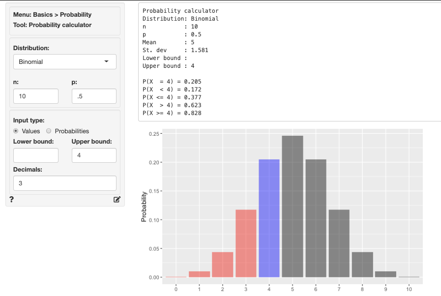

##### ロジスティック回帰分析とロジット関数 * ロジスティック回帰分析は試行回数nがわかっている状況で，成功確率pを求める． - pは確率であるために0-1の値しかとらない．

$$p=\frac{1}{1+exp\{-(ax+b)\}}$$

- exp(X)：eのX乗
- 線形予測子(ax+b)が小さくなる→分母が大きくなる→成功確率が0に近づく
- 線形予測子(ax+b)が大きくなる→分母が小さくなる→成功確率が1に近づく
- ロジット関数：ロジスティック関数の逆関数．両辺にロジット関数を適用すると，線形予測子が見やすくなる．

$$ln(\frac{p}{1-p}) = ax + b$$

##### オッズ * 失敗するよりも何倍成功しやすいか - ex.オッズが2であれば失敗するよりも2倍成功しやすい．

- 成功確率をpとするとオッズは**$\frac{p}{1-p}$**
  - ex. p=1/2であれば，成功確率と失敗確率は等しくなる：オッズは$\frac{1/2}{1-(1/2)}=\frac{1/2}{1/2}=1$
  - ex. p=3/4であれば失敗確率は1/4となる：オッズは$\frac{3/4}{1-(3/4)}=\frac{3/4}{1/4}=3$
  - 対数オッズ：オッズにログをとったもの **$ln(\frac{p}{1-p}$)**
  - 実際には対数オッズは解釈しにくいためにexpをとってオッズに戻してから解釈する．
- この観点からもう一度，前回の講義を解釈してみましょう．
- 分析結果

```r
library(radiant)
result <- logistic(
  titanic,
  rvar = "survived",
  evar = "sex",
  lev = "Yes"
)
summary(result, sum_check = c("confint", "odds"))
```

```
## Logistic regression (GLM)
## Data                 : titanic
## Response variable    : survived
## Level                : Yes in survived
## Explanatory variables: sex
## Null hyp.: there is no effect of sex on survived
## Alt. hyp.: there is an effect of sex on survived
##
##                 OR coefficient std.error z.value p.value
##  (Intercept)             1.106     0.118   9.389  < .001 ***
##  sex|male    0.086      -2.458     0.152 -16.141  < .001 ***
##
## Signif. codes:  0 '***' 0.001 '**' 0.01 '*' 0.05 '.' 0.1 ' ' 1
##
## Pseudo R-squared: 0.22
## Log-likelihood: -550.204, AIC: 1104.408, BIC: 1114.308
## Chi-squared: 309.577 df(1), p.value < .001
## Nr obs: 1,043
```

```
##             coefficient   2.5%  97.5%   +/-
## (Intercept)       1.106  0.879  1.341 0.236
## sex|male         -2.458 -2.761 -2.163 0.295
##
##          odds ratio  2.5% 97.5%
## sex|male      0.086 0.063 0.115
```

- オッズ比が0.086である．
- 性別のcoefficientsが-2.458→expをとってオッズ比にして考える．
- 男性の方が女性に比べて0.086倍助かりやすい．
- さらにいろんなデータを入れて分析をしてみましょう．
- titanicデータについて，どのようなデータが生存率に影響を与えるのか確認せよ．
- 前回の演習問題の復習
- 名前以外を全投入します．
- VIFの値を確認します．
- VIF：Variance Inflation Factor，説明変数同士の多重共線性を検出する指標の1つ．この値がおおよそ10を超えた場合はその変数を分析から除いたほうが良い．
- その他，有意性などを考慮しながら分析を行う．
- 同様に確認しよう．

### さらなる分析をしてみよう．

> spamデータはヒューレット・パッカード社の研究所が57個の変数とともに，迷惑メールか否かを分析したデータである．
- データの読み込み

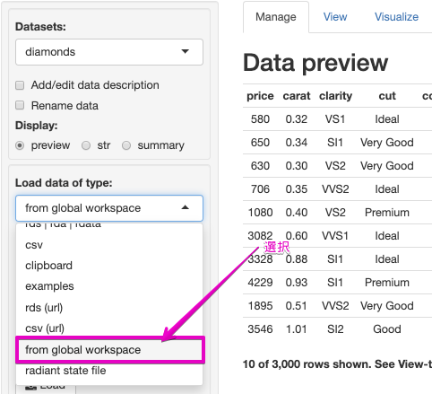

  - Global Env(RStudio)からの読み込み

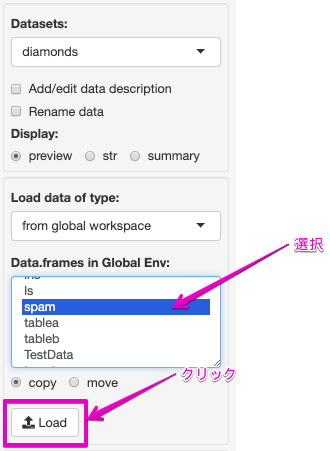

  - データの58列にある“type”がspamメールであるか，スパムメールでないかを判断している．

#### モデル選択基準としてステップワイズ法を使ってみよう

- ステップワイズ法：独立変数を選択する方法の1つとして用いられる．
- 1つずつ説明変数を追加したり，削除をしたりしながら最適な説明変数の組み合わせを探す．
- ステップワイズ法の種類
- 変数増加法：説明変数なしモデルからはじめて，1つずつ説明変数を増やす．
- 変数減少法：全ての説明変数モデルからはじめて，1つずつ説明変数を減らす．*今回はこれ*
  - 変数増減法：説明変数なしモデルから初めて，1つずつ説明変数を増やしたり，減らしたりする．
- 変数減増法：全ての説明変数モデルからはじめて，1つずつ説明変数を増やしたり，減らしたりする．
- モデルの評価基準
- AICだったり，BICだったりRMSEだったり．
- step関数ではAICに基づきモデル評価を行う．
- 様々な評価指標があるので，その時のモデルに合わせた分析を行う．

#### R上で今回と同じことをやる方法

```r
library(kernlab)
data(spam)
model <-glm(type ~ ., spam, family="binomial")
summary(model)
```

```
##
## Call:
## glm(formula = type ~ ., family = "binomial", data = spam)
##
## Deviance Residuals:
##    Min      1Q  Median      3Q     Max
## -4.127  -0.203   0.000   0.114   5.364
##
## Coefficients:
##                     Estimate Std. Error z value Pr(>|z|)
## (Intercept)       -1.569e+00  1.420e-01 -11.044  < 2e-16 ***
## make              -3.895e-01  2.315e-01  -1.683 0.092388 .
## address           -1.458e-01  6.928e-02  -2.104 0.035362 *
## all                1.141e-01  1.103e-01   1.035 0.300759
## num3d              2.252e+00  1.507e+00   1.494 0.135168
## our                5.624e-01  1.018e-01   5.524 3.31e-08 ***
## over               8.830e-01  2.498e-01   3.534 0.000409 ***
## remove             2.279e+00  3.328e-01   6.846 7.57e-12 ***
## internet           5.696e-01  1.682e-01   3.387 0.000707 ***
## order              7.343e-01  2.849e-01   2.577 0.009958 **
## mail               1.275e-01  7.262e-02   1.755 0.079230 .
## receive           -2.557e-01  2.979e-01  -0.858 0.390655
## will              -1.383e-01  7.405e-02  -1.868 0.061773 .
## people            -7.961e-02  2.303e-01  -0.346 0.729557
## report             1.447e-01  1.364e-01   1.061 0.288855
## addresses          1.236e+00  7.254e-01   1.704 0.088370 .
## free               1.039e+00  1.457e-01   7.128 1.01e-12 ***
## business           9.599e-01  2.251e-01   4.264 2.01e-05 ***
## email              1.203e-01  1.172e-01   1.027 0.304533
## you                8.131e-02  3.505e-02   2.320 0.020334 *
## credit             1.047e+00  5.383e-01   1.946 0.051675 .
## your               2.419e-01  5.243e-02   4.615 3.94e-06 ***
## font               2.013e-01  1.627e-01   1.238 0.215838
## num000             2.245e+00  4.714e-01   4.762 1.91e-06 ***
## money              4.264e-01  1.621e-01   2.630 0.008535 **
## hp                -1.920e+00  3.128e-01  -6.139 8.31e-10 ***
## hpl               -1.040e+00  4.396e-01  -2.366 0.017966 *
## george            -1.177e+01  2.113e+00  -5.569 2.57e-08 ***
## num650             4.454e-01  1.991e-01   2.237 0.025255 *
## lab               -2.486e+00  1.502e+00  -1.656 0.097744 .
```

[output cut: 23 more lines]

```
## charDollar         5.336e+00  7.064e-01   7.553 4.24e-14 ***
## charHash           2.403e+00  1.113e+00   2.159 0.030883 *
## capitalAve         1.199e-02  1.884e-02   0.636 0.524509
## capitalLong        9.118e-03  2.521e-03   3.618 0.000297 ***
## capitalTotal       8.437e-04  2.251e-04   3.747 0.000179 ***
## ---
## Signif. codes:  0 '***' 0.001 '**' 0.01 '*' 0.05 '.' 0.1 ' ' 1
##
## (Dispersion parameter for binomial family taken to be 1)
##
##     Null deviance: 6170.2  on 4600  degrees of freedom
## Residual deviance: 1815.8  on 4543  degrees of freedom
## AIC: 1931.8
##
## Number of Fisher Scoring iterations: 13
```

```r
stepmodel<-step(model)
```

```
## Start:  AIC=1931.77
## type ~ make + address + all + num3d + our + over + remove + internet +
##     order + mail + receive + will + people + report + addresses +
##     free + business + email + you + credit + your + font + num000 +
##     money + hp + hpl + george + num650 + lab + labs + telnet +
##     num857 + data + num415 + num85 + technology + num1999 + parts +
##     pm + direct + cs + meeting + original + project + re + edu +
##     table + conference + charSemicolon + charRoundbracket + charSquarebracket +
##     charExclamation + charDollar + charHash + capitalAve + capitalLong +
##     capitalTotal
```

[output not shown]

[output cut: 58 more lines]

[output not shown]

```
##                     Df Deviance    AIC
## - num1999            1   1815.8 1929.8
## - people             1   1815.9 1929.9
## - num415             1   1816.0 1930.0
## - telnet             1   1816.0 1930.0
## - capitalAve         1   1816.2 1930.2
## - charRoundbracket   1   1816.4 1930.4
## - num857             1   1816.4 1930.4
## - receive            1   1816.5 1930.5
## - direct             1   1816.5 1930.5
## - charSquarebracket  1   1816.8 1930.8
## - all                1   1816.8 1930.8
## - email              1   1816.8 1930.8
## - report             1   1816.8 1930.8
## - labs               1   1817.0 1931.0
## - font               1   1817.8 1931.8
## <none>                   1815.8 1931.8
## - make               1   1818.9 1932.9
## - mail               1   1819.1 1933.1
## - parts              1   1819.4 1933.4
## - addresses          1   1819.4 1933.4
## - will               1   1819.5 1933.5
## - original           1   1820.4 1934.4
## - table              1   1820.5 1934.5
## - you                1   1821.0 1935.0
## - charHash           1   1822.3 1936.3
## - order              1   1822.8 1936.8
## - num650             1   1823.1 1937.1
## - pm                 1   1823.2 1937.2
## - hpl                1   1824.0 1938.0
## - address            1   1824.0 1938.0
## - num85              1   1824.4 1938.4
## - technology         1   1824.4 1938.4
## - num3d              1   1824.9 1938.9
## - lab                1   1826.0 1940.0
## - data               1   1826.9 1940.9
## - money              1   1827.9 1941.9
## - credit             1   1828.0 1942.0
## - capitalLong        1   1830.0 1944.0
## - over               1   1831.4 1945.4
## - conference         1   1832.7 1946.7
## - internet           1   1833.1 1947.1
## - charSemicolon      1   1833.4 1947.4
## - project            1   1834.7 1948.7
## - capitalTotal       1   1835.9 1949.9
## - your               1   1837.9 1951.9
## - business           1   1838.8 1952.8
## - cs                 1   1841.3 1955.3
## - charExclamation    1   1845.8 1959.8
## - our                1   1854.5 1968.5
## - num000             1   1857.3 1971.3
## - re                 1   1864.0 1978.0
## - meeting            1   1867.8 1981.8
## - edu                1   1883.5 1997.5
## - free               1   1904.2 2018.2
## - charDollar         1   1905.2 2019.2
## - remove             1   1916.7 2030.7
## - hp                 1   1938.0 2052.0
## - george             1   2059.4 2173.4
```

```
##
## Step:  AIC=1929.84
## type ~ make + address + all + num3d + our + over + remove + internet +
##     order + mail + receive + will + people + report + addresses +
##     free + business + email + you + credit + your + font + num000 +
##     money + hp + hpl + george + num650 + lab + labs + telnet +
##     num857 + data + num415 + num85 + technology + parts + pm +
##     direct + cs + meeting + original + project + re + edu + table +
##     conference + charSemicolon + charRoundbracket + charSquarebracket +
##     charExclamation + charDollar + charHash + capitalAve + capitalLong +
##     capitalTotal
```

[output not shown]

[output cut: 56 more lines]

[output not shown]

```
##                     Df Deviance    AIC
## - people             1   1816.0 1928.0
## - num415             1   1816.0 1928.0
## - telnet             1   1816.1 1928.1
## - capitalAve         1   1816.3 1928.3
## - charRoundbracket   1   1816.4 1928.4
## - num857             1   1816.5 1928.5
## - receive            1   1816.6 1928.6
## - direct             1   1816.6 1928.6
## - charSquarebracket  1   1816.8 1928.8
## - email              1   1816.9 1928.9
## - all                1   1816.9 1928.9
## - report             1   1816.9 1928.9
## - labs               1   1817.1 1929.1
## - font               1   1817.8 1929.8
## <none>                   1815.8 1929.8
## - make               1   1819.0 1931.0
## - mail               1   1819.1 1931.1
## - parts              1   1819.4 1931.4
## - addresses          1   1819.5 1931.5
## - will               1   1819.6 1931.6
## - original           1   1820.4 1932.4
## - table              1   1820.5 1932.5
## - you                1   1821.1 1933.1
## - charHash           1   1822.4 1934.4
## - order              1   1822.9 1934.9
## - num650             1   1823.1 1935.1
## - pm                 1   1823.2 1935.2
## - hpl                1   1824.0 1936.0
## - address            1   1824.1 1936.1
## - technology         1   1824.4 1936.4
## - num85              1   1824.5 1936.5
## - num3d              1   1824.9 1936.9
## - lab                1   1826.1 1938.1
## - data               1   1826.9 1938.9
## - money              1   1827.9 1939.9
## - credit             1   1828.0 1940.0
## - capitalLong        1   1830.0 1942.0
## - over               1   1831.4 1943.4
## - conference         1   1832.7 1944.7
## - internet           1   1833.2 1945.2
## - charSemicolon      1   1833.4 1945.4
## - project            1   1834.8 1946.8
## - capitalTotal       1   1836.1 1948.1
## - your               1   1837.9 1949.9
## - business           1   1838.9 1950.9
## - cs                 1   1841.3 1953.3
## - charExclamation    1   1845.8 1957.8
## - our                1   1854.6 1966.6
## - num000             1   1857.3 1969.3
## - re                 1   1864.2 1976.2
## - meeting            1   1867.9 1979.9
## - edu                1   1883.9 1995.9
## - free               1   1904.2 2016.2
## - charDollar         1   1905.2 2017.2
## - remove             1   1916.7 2028.7
## - hp                 1   1938.0 2050.0
## - george             1   2059.4 2171.4
```

```
##
## Step:  AIC=1927.96
## type ~ make + address + all + num3d + our + over + remove + internet +
##     order + mail + receive + will + report + addresses + free +
##     business + email + you + credit + your + font + num000 +
##     money + hp + hpl + george + num650 + lab + labs + telnet +
##     num857 + data + num415 + num85 + technology + parts + pm +
##     direct + cs + meeting + original + project + re + edu + table +
##     conference + charSemicolon + charRoundbracket + charSquarebracket +
##     charExclamation + charDollar + charHash + capitalAve + capitalLong +
##     capitalTotal
```

[output not shown]

[output cut: 54 more lines]

[output not shown]

```
##                     Df Deviance    AIC
## - num415             1   1816.2 1926.2
## - telnet             1   1816.2 1926.2
## - capitalAve         1   1816.4 1926.4
## - charRoundbracket   1   1816.5 1926.5
## - num857             1   1816.6 1926.6
## - receive            1   1816.7 1926.7
## - direct             1   1816.8 1926.8
## - charSquarebracket  1   1817.0 1927.0
## - all                1   1817.0 1927.0
## - email              1   1817.0 1927.0
## - report             1   1817.0 1927.0
## - labs               1   1817.2 1927.2
## - font               1   1817.9 1927.9
## <none>                   1816.0 1928.0
## - make               1   1819.1 1929.1
## - mail               1   1819.3 1929.3
## - addresses          1   1819.5 1929.5
## - parts              1   1819.6 1929.6
## - will               1   1819.7 1929.7
## - original           1   1820.5 1930.5
## - table              1   1820.7 1930.7
## - you                1   1821.2 1931.2
## - charHash           1   1822.5 1932.5
## - order              1   1823.1 1933.1
## - num650             1   1823.3 1933.3
## - pm                 1   1823.4 1933.4
## - hpl                1   1824.0 1934.0
## - address            1   1824.2 1934.2
## - num85              1   1824.5 1934.5
## - technology         1   1824.6 1934.6
## - num3d              1   1825.1 1935.1
## - lab                1   1826.3 1936.3
## - data               1   1827.0 1937.0
## - money              1   1828.0 1938.0
## - credit             1   1828.2 1938.2
## - capitalLong        1   1830.1 1940.1
## - over               1   1831.5 1941.5
## - conference         1   1832.8 1942.8
## - internet           1   1833.4 1943.4
## - charSemicolon      1   1833.5 1943.5
## - project            1   1835.0 1945.0
## - capitalTotal       1   1836.2 1946.2
## - your               1   1838.2 1948.2
## - business           1   1838.9 1948.9
## - cs                 1   1841.4 1951.4
## - charExclamation    1   1846.0 1956.0
## - our                1   1854.6 1964.6
## - num000             1   1857.3 1967.3
## - re                 1   1864.2 1974.2
## - meeting            1   1868.0 1978.0
## - edu                1   1884.4 1994.4
## - free               1   1905.0 2015.0
## - charDollar         1   1906.9 2016.9
## - remove             1   1916.8 2026.8
## - hp                 1   1938.5 2048.5
## - george             1   2059.8 2169.8
```

```
##
## Step:  AIC=1926.16
## type ~ make + address + all + num3d + our + over + remove + internet +
##     order + mail + receive + will + report + addresses + free +
##     business + email + you + credit + your + font + num000 +
##     money + hp + hpl + george + num650 + lab + labs + telnet +
##     num857 + data + num85 + technology + parts + pm + direct +
##     cs + meeting + original + project + re + edu + table + conference +
##     charSemicolon + charRoundbracket + charSquarebracket + charExclamation +
##     charDollar + charHash + capitalAve + capitalLong + capitalTotal
```

[output not shown]

[output cut: 52 more lines]

[output not shown]

```
##                     Df Deviance    AIC
## - telnet             1   1816.4 1924.4
## - capitalAve         1   1816.6 1924.6
## - charRoundbracket   1   1816.7 1924.7
## - num857             1   1816.8 1924.8
## - receive            1   1816.9 1924.9
## - direct             1   1817.0 1925.0
## - charSquarebracket  1   1817.1 1925.1
## - all                1   1817.2 1925.2
## - email              1   1817.2 1925.2
## - report             1   1817.2 1925.2
## - labs               1   1817.4 1925.4
## - font               1   1818.1 1926.1
## <none>                   1816.2 1926.2
## - make               1   1819.2 1927.2
## - mail               1   1819.5 1927.5
## - addresses          1   1819.7 1927.7
## - parts              1   1819.8 1927.8
## - will               1   1820.0 1928.0
## - original           1   1820.7 1928.7
## - table              1   1820.9 1928.9
## - you                1   1821.3 1929.3
## - charHash           1   1822.7 1930.7
## - order              1   1823.2 1931.2
## - num650             1   1823.5 1931.5
## - pm                 1   1823.6 1931.6
## - hpl                1   1824.2 1932.2
## - address            1   1824.4 1932.4
## - num85              1   1824.8 1932.8
## - technology         1   1824.8 1932.8
## - num3d              1   1825.2 1933.2
## - lab                1   1826.5 1934.5
## - data               1   1827.2 1935.2
## - money              1   1828.2 1936.2
## - credit             1   1828.3 1936.3
## - capitalLong        1   1830.3 1938.3
## - over               1   1831.6 1939.6
## - conference         1   1833.0 1941.0
## - internet           1   1833.5 1941.5
## - charSemicolon      1   1833.7 1941.7
## - project            1   1835.2 1943.2
## - capitalTotal       1   1836.5 1944.5
## - your               1   1838.5 1946.5
## - business           1   1839.1 1947.1
## - cs                 1   1841.6 1949.6
## - charExclamation    1   1846.6 1954.6
## - our                1   1854.8 1962.8
## - num000             1   1857.5 1965.5
## - re                 1   1864.5 1972.5
## - meeting            1   1868.2 1976.2
## - edu                1   1884.6 1992.6
## - free               1   1905.1 2013.1
## - charDollar         1   1907.5 2015.5
## - remove             1   1917.0 2025.0
## - hp                 1   1938.7 2046.7
## - george             1   2060.3 2168.3
```

```
##
## Step:  AIC=1924.41
## type ~ make + address + all + num3d + our + over + remove + internet +
##     order + mail + receive + will + report + addresses + free +
##     business + email + you + credit + your + font + num000 +
##     money + hp + hpl + george + num650 + lab + labs + num857 +
##     data + num85 + technology + parts + pm + direct + cs + meeting +
##     original + project + re + edu + table + conference + charSemicolon +
##     charRoundbracket + charSquarebracket + charExclamation +
##     charDollar + charHash + capitalAve + capitalLong + capitalTotal
```

[output not shown]

[output cut: 50 more lines]

[output not shown]

```
##                     Df Deviance    AIC
## - capitalAve         1   1816.8 1922.8
## - charRoundbracket   1   1817.0 1923.0
## - num857             1   1817.1 1923.1
## - receive            1   1817.2 1923.2
## - direct             1   1817.2 1923.2
## - charSquarebracket  1   1817.4 1923.4
## - all                1   1817.5 1923.5
## - email              1   1817.5 1923.5
## - report             1   1817.5 1923.5
## - labs               1   1817.6 1923.6
## - font               1   1818.4 1924.4
## <none>                   1816.4 1924.4
## - make               1   1819.5 1925.5
## - mail               1   1819.8 1925.8
## - addresses          1   1819.9 1925.9
## - parts              1   1820.0 1926.0
## - will               1   1820.2 1926.2
## - original           1   1821.0 1927.0
## - table              1   1821.1 1927.1
## - you                1   1821.6 1927.6
## - charHash           1   1823.0 1929.0
## - order              1   1823.5 1929.5
## - num650             1   1823.7 1929.7
## - pm                 1   1823.8 1929.8
## - hpl                1   1824.4 1930.4
## - address            1   1824.6 1930.6
## - technology         1   1825.1 1931.1
## - num85              1   1825.2 1931.2
## - num3d              1   1825.5 1931.5
## - lab                1   1826.7 1932.7
## - data               1   1827.4 1933.4
## - money              1   1828.5 1934.5
## - credit             1   1828.6 1934.6
## - capitalLong        1   1830.5 1936.5
## - over               1   1831.9 1937.9
## - conference         1   1833.3 1939.3
## - internet           1   1833.8 1939.8
## - charSemicolon      1   1833.9 1939.9
## - capitalTotal       1   1836.8 1942.8
## - project            1   1837.6 1943.6
## - your               1   1838.7 1944.7
## - business           1   1839.4 1945.4
## - cs                 1   1841.9 1947.9
## - charExclamation    1   1846.9 1952.9
## - our                1   1855.1 1961.1
## - num000             1   1857.8 1963.8
## - re                 1   1864.7 1970.7
## - meeting            1   1868.4 1974.4
## - edu                1   1884.8 1990.8
## - free               1   1905.3 2011.3
## - charDollar         1   1907.9 2013.9
## - remove             1   1917.3 2023.3
## - hp                 1   1941.2 2047.2
## - george             1   2064.2 2170.2
```

```
##
## Step:  AIC=1922.85
## type ~ make + address + all + num3d + our + over + remove + internet +
##     order + mail + receive + will + report + addresses + free +
##     business + email + you + credit + your + font + num000 +
##     money + hp + hpl + george + num650 + lab + labs + num857 +
##     data + num85 + technology + parts + pm + direct + cs + meeting +
##     original + project + re + edu + table + conference + charSemicolon +
##     charRoundbracket + charSquarebracket + charExclamation +
##     charDollar + charHash + capitalLong + capitalTotal
```

[output not shown]

[output cut: 48 more lines]

[output not shown]

```
##                     Df Deviance    AIC
## - charRoundbracket   1   1817.4 1921.4
## - num857             1   1817.5 1921.5
## - receive            1   1817.6 1921.6
## - direct             1   1817.6 1921.6
## - email              1   1817.8 1921.8
## - charSquarebracket  1   1817.8 1921.8
## - report             1   1817.8 1921.8
## - all                1   1817.8 1921.8
## - labs               1   1818.0 1922.0
## <none>                   1816.8 1922.8
## - font               1   1818.9 1922.9
## - make               1   1819.8 1923.8
## - addresses          1   1820.3 1924.3
## - mail               1   1820.4 1924.4
## - parts              1   1820.5 1924.5
## - will               1   1820.7 1924.7
## - original           1   1821.5 1925.5
## - table              1   1821.5 1925.5
## - you                1   1822.0 1926.0
## - charHash           1   1823.5 1927.5
## - order              1   1823.6 1927.6
## - num650             1   1824.2 1928.2
## - pm                 1   1824.3 1928.3
## - hpl                1   1824.8 1928.8
## - address            1   1825.2 1929.2
## - technology         1   1825.6 1929.6
## - num3d              1   1825.9 1929.9
## - num85              1   1826.2 1930.2
## - lab                1   1827.1 1931.1
## - data               1   1828.0 1932.0
## - credit             1   1828.8 1932.8
## - money              1   1829.0 1933.0
## - over               1   1832.0 1936.0
## - conference         1   1833.7 1937.7
## - internet           1   1834.3 1938.3
## - charSemicolon      1   1834.5 1938.5
## - capitalTotal       1   1836.9 1940.9
## - project            1   1838.0 1942.0
## - your               1   1839.2 1943.2
## - business           1   1839.6 1943.6
## - cs                 1   1842.0 1946.0
## - charExclamation    1   1847.7 1951.7
## - capitalLong        1   1853.2 1957.2
## - our                1   1855.5 1959.5
## - num000             1   1858.2 1962.2
## - re                 1   1865.2 1969.2
## - meeting            1   1869.8 1973.8
## - edu                1   1885.5 1989.5
## - free               1   1906.5 2010.5
## - charDollar         1   1908.1 2012.1
## - remove             1   1918.4 2022.4
## - hp                 1   1941.8 2045.8
## - george             1   2065.5 2169.5
```

```
##
## Step:  AIC=1921.4
## type ~ make + address + all + num3d + our + over + remove + internet +
##     order + mail + receive + will + report + addresses + free +
##     business + email + you + credit + your + font + num000 +
##     money + hp + hpl + george + num650 + lab + labs + num857 +
##     data + num85 + technology + parts + pm + direct + cs + meeting +
##     original + project + re + edu + table + conference + charSemicolon +
##     charSquarebracket + charExclamation + charDollar + charHash +
##     capitalLong + capitalTotal
```

[output not shown]

[output cut: 46 more lines]

[output not shown]

```
##                     Df Deviance    AIC
## - num857             1   1818.1 1920.1
## - receive            1   1818.2 1920.2
## - direct             1   1818.2 1920.2
## - charSquarebracket  1   1818.4 1920.4
## - email              1   1818.4 1920.4
## - all                1   1818.4 1920.4
## - report             1   1818.4 1920.4
## - labs               1   1818.5 1920.5
## <none>                   1817.4 1921.4
## - font               1   1819.6 1921.6
## - make               1   1820.4 1922.4
## - addresses          1   1820.9 1922.9
## - mail               1   1820.9 1922.9
## - parts              1   1821.0 1923.0
## - will               1   1821.2 1923.2
## - original           1   1822.0 1924.0
## - table              1   1822.1 1924.1
## - you                1   1823.0 1925.0
## - charHash           1   1824.1 1926.1
## - order              1   1824.1 1926.1
## - num650             1   1824.2 1926.2
## - pm                 1   1824.8 1926.8
## - hpl                1   1825.4 1927.4
## - address            1   1825.5 1927.5
## - technology         1   1826.2 1928.2
## - num3d              1   1826.5 1928.5
## - num85              1   1826.6 1928.6
## - lab                1   1827.7 1929.7
## - data               1   1828.5 1930.5
## - credit             1   1829.4 1931.4
## - money              1   1829.5 1931.5
## - over               1   1832.4 1934.4
## - conference         1   1834.2 1936.2
## - charSemicolon      1   1835.0 1937.0
## - internet           1   1835.1 1937.1
## - capitalTotal       1   1837.4 1939.4
## - project            1   1838.4 1940.4
## - business           1   1840.1 1942.1
## - your               1   1840.1 1942.1
## - cs                 1   1842.5 1944.5
## - charExclamation    1   1848.4 1950.4
## - capitalLong        1   1854.0 1956.0
## - our                1   1856.4 1958.4
## - num000             1   1858.6 1960.6
## - re                 1   1866.0 1968.0
## - meeting            1   1870.5 1972.5
## - edu                1   1885.9 1987.9
## - free               1   1907.1 2009.1
## - charDollar         1   1908.5 2010.5
## - remove             1   1919.2 2021.2
## - hp                 1   1942.0 2044.0
## - george             1   2065.7 2167.7
```

```
##
## Step:  AIC=1920.06
## type ~ make + address + all + num3d + our + over + remove + internet +
##     order + mail + receive + will + report + addresses + free +
##     business + email + you + credit + your + font + num000 +
##     money + hp + hpl + george + num650 + lab + labs + data +
##     num85 + technology + parts + pm + direct + cs + meeting +
##     original + project + re + edu + table + conference + charSemicolon +
##     charSquarebracket + charExclamation + charDollar + charHash +
##     capitalLong + capitalTotal
```

[output not shown]

[output cut: 44 more lines]

[output not shown]

```
##                     Df Deviance    AIC
## - receive            1   1818.8 1918.8
## - direct             1   1818.8 1918.8
## - charSquarebracket  1   1819.0 1919.0
## - report             1   1819.1 1919.1
## - email              1   1819.1 1919.1
## - all                1   1819.1 1919.1
## - labs               1   1819.2 1919.2
## <none>                   1818.1 1920.1
## - font               1   1820.2 1920.2
## - make               1   1821.1 1921.1
## - addresses          1   1821.5 1921.5
## - mail               1   1821.6 1921.6
## - parts              1   1821.6 1921.6
## - will               1   1821.8 1921.8
## - original           1   1822.7 1922.7
## - table              1   1822.8 1922.8
## - you                1   1823.5 1923.5
## - order              1   1824.7 1924.7
## - charHash           1   1824.7 1924.7
## - num650             1   1824.8 1924.8
## - pm                 1   1825.5 1925.5
## - address            1   1826.0 1926.0
## - hpl                1   1826.0 1926.0
## - technology         1   1826.9 1926.9
## - num3d              1   1827.1 1927.1
## - num85              1   1827.3 1927.3
## - lab                1   1828.4 1928.4
## - data               1   1829.2 1929.2
## - money              1   1830.3 1930.3
## - credit             1   1830.6 1930.6
## - over               1   1833.0 1933.0
## - conference         1   1834.9 1934.9
## - charSemicolon      1   1835.5 1935.5
## - internet           1   1835.7 1935.7
## - capitalTotal       1   1838.2 1938.2
## - project            1   1839.3 1939.3
## - business           1   1840.6 1940.6
## - your               1   1841.1 1941.1
## - cs                 1   1843.2 1943.2
## - charExclamation    1   1849.1 1949.1
## - capitalLong        1   1854.5 1954.5
## - our                1   1856.8 1956.8
## - num000             1   1859.2 1959.2
## - re                 1   1866.8 1966.8
## - meeting            1   1871.2 1971.2
## - edu                1   1886.7 1986.7
## - free               1   1907.5 2007.5
## - charDollar         1   1908.8 2008.8
## - remove             1   1919.6 2019.6
## - hp                 1   1943.2 2043.2
## - george             1   2069.8 2169.8
```

```
##
## Step:  AIC=1918.84
## type ~ make + address + all + num3d + our + over + remove + internet +
##     order + mail + will + report + addresses + free + business +
##     email + you + credit + your + font + num000 + money + hp +
##     hpl + george + num650 + lab + labs + data + num85 + technology +
##     parts + pm + direct + cs + meeting + original + project +
##     re + edu + table + conference + charSemicolon + charSquarebracket +
##     charExclamation + charDollar + charHash + capitalLong + capitalTotal
```

[output not shown]

[output cut: 42 more lines]

[output not shown]

```
##                     Df Deviance    AIC
## - direct             1   1819.7 1917.7
## - report             1   1819.8 1917.8
## - email              1   1819.8 1917.8
## - charSquarebracket  1   1819.8 1917.8
## - all                1   1820.0 1918.0
## - labs               1   1820.0 1918.0
## <none>                   1818.8 1918.8
## - font               1   1820.9 1918.9
## - mail               1   1822.2 1920.2
## - addresses          1   1822.3 1920.3
## - parts              1   1822.4 1920.4
## - will               1   1822.9 1920.9
## - table              1   1823.4 1921.4
## - original           1   1823.5 1921.5
## - make               1   1823.8 1921.8
## - you                1   1824.3 1922.3
## - order              1   1825.5 1923.5
## - charHash           1   1825.5 1923.5
## - num650             1   1825.6 1923.6
## - pm                 1   1826.2 1924.2
## - hpl                1   1826.7 1924.7
## - address            1   1826.9 1924.9
## - technology         1   1827.6 1925.6
## - num3d              1   1828.0 1926.0
## - num85              1   1828.0 1926.0
## - lab                1   1828.9 1926.9
## - data               1   1830.0 1928.0
## - credit             1   1831.1 1929.1
## - money              1   1831.4 1929.4
## - over               1   1833.8 1931.8
## - conference         1   1835.7 1933.7
## - internet           1   1836.2 1934.2
## - charSemicolon      1   1836.4 1934.4
## - capitalTotal       1   1838.9 1936.9
## - project            1   1840.0 1938.0
## - your               1   1841.3 1939.3
## - business           1   1841.9 1939.9
## - cs                 1   1843.9 1941.9
## - charExclamation    1   1849.8 1947.8
## - capitalLong        1   1855.2 1953.2
## - our                1   1857.6 1955.6
## - num000             1   1859.6 1957.6
## - re                 1   1867.2 1965.2
## - meeting            1   1871.9 1969.9
## - edu                1   1887.3 1985.3
## - free               1   1907.5 2005.5
## - charDollar         1   1910.5 2008.5
## - remove             1   1919.6 2017.6
## - hp                 1   1944.7 2042.7
## - george             1   2069.9 2167.9
```

```
##
## Step:  AIC=1917.66
## type ~ make + address + all + num3d + our + over + remove + internet +
##     order + mail + will + report + addresses + free + business +
##     email + you + credit + your + font + num000 + money + hp +
##     hpl + george + num650 + lab + labs + data + num85 + technology +
##     parts + pm + cs + meeting + original + project + re + edu +
##     table + conference + charSemicolon + charSquarebracket +
##     charExclamation + charDollar + charHash + capitalLong + capitalTotal
```

[output not shown]

[output cut: 40 more lines]

[output not shown]

```
##                     Df Deviance    AIC
## - email              1   1820.6 1916.6
## - charSquarebracket  1   1820.6 1916.6
## - report             1   1820.6 1916.6
## - all                1   1820.8 1916.8
## - labs               1   1820.8 1916.8
## <none>                   1819.7 1917.7
## - font               1   1822.1 1918.1
## - mail               1   1822.9 1918.9
## - addresses          1   1823.1 1919.1
## - parts              1   1823.2 1919.2
## - will               1   1823.7 1919.7
## - table              1   1824.3 1920.3
## - original           1   1824.3 1920.3
## - make               1   1824.5 1920.5
## - you                1   1825.3 1921.3
## - charHash           1   1825.8 1921.8
## - order              1   1826.1 1922.1
## - num650             1   1826.5 1922.5
## - pm                 1   1827.0 1923.0
## - hpl                1   1827.4 1923.4
## - address            1   1827.6 1923.6
## - technology         1   1828.4 1924.4
## - num3d              1   1828.8 1924.8
## - num85              1   1828.9 1924.9
## - lab                1   1829.7 1925.7
## - data               1   1830.7 1926.7
## - credit             1   1831.9 1927.9
## - money              1   1832.3 1928.3
## - over               1   1834.7 1930.7
## - conference         1   1836.7 1932.7
## - internet           1   1837.1 1933.1
## - charSemicolon      1   1837.3 1933.3
## - capitalTotal       1   1839.9 1935.9
## - project            1   1840.5 1936.5
## - your               1   1842.0 1938.0
## - business           1   1842.5 1938.5
## - cs                 1   1844.7 1940.7
## - charExclamation    1   1850.7 1946.7
## - capitalLong        1   1856.1 1952.1
## - our                1   1858.5 1954.5
## - num000             1   1860.3 1956.3
## - re                 1   1867.8 1963.8
## - meeting            1   1872.3 1968.3
## - edu                1   1887.8 1983.8
## - free               1   1908.3 2004.3
## - charDollar         1   1911.7 2007.7
## - remove             1   1920.0 2016.0
## - hp                 1   1944.8 2040.8
## - george             1   2079.8 2175.8
```

```
##
## Step:  AIC=1916.6
## type ~ make + address + all + num3d + our + over + remove + internet +
##     order + mail + will + report + addresses + free + business +
##     you + credit + your + font + num000 + money + hp + hpl +
##     george + num650 + lab + labs + data + num85 + technology +
##     parts + pm + cs + meeting + original + project + re + edu +
##     table + conference + charSemicolon + charSquarebracket +
##     charExclamation + charDollar + charHash + capitalLong + capitalTotal
```

[output not shown]

[output cut: 38 more lines]

[output not shown]

```
##                     Df Deviance    AIC
## - report             1   1821.5 1915.5
## - charSquarebracket  1   1821.5 1915.5
## - all                1   1821.8 1915.8
## - labs               1   1821.8 1915.8
## <none>                   1820.6 1916.6
## - font               1   1823.0 1917.0
## - mail               1   1823.8 1917.8
## - parts              1   1824.2 1918.2
## - will               1   1824.6 1918.6
## - addresses          1   1824.8 1918.8
## - table              1   1825.0 1919.0
## - original           1   1825.3 1919.3
## - make               1   1825.7 1919.7
## - charHash           1   1826.5 1920.5
## - you                1   1826.7 1920.7
## - order              1   1826.9 1920.9
## - num650             1   1827.5 1921.5
## - pm                 1   1828.1 1922.1
## - address            1   1828.3 1922.3
## - hpl                1   1828.4 1922.4
## - technology         1   1829.3 1923.3
## - num3d              1   1829.7 1923.7
## - num85              1   1830.0 1924.0
## - lab                1   1830.8 1924.8
## - data               1   1831.8 1925.8
## - credit             1   1832.7 1926.7
## - money              1   1833.0 1927.0
## - over               1   1835.4 1929.4
## - conference         1   1837.8 1931.8
## - internet           1   1838.2 1932.2
## - charSemicolon      1   1838.4 1932.4
## - capitalTotal       1   1840.6 1934.6
## - project            1   1841.5 1935.5
## - your               1   1843.1 1937.1
## - business           1   1843.8 1937.8
## - cs                 1   1845.2 1939.2
## - charExclamation    1   1851.5 1945.5
## - capitalLong        1   1857.9 1951.9
## - our                1   1859.6 1953.6
## - num000             1   1860.8 1954.8
## - re                 1   1870.2 1964.2
## - meeting            1   1873.8 1967.8
## - edu                1   1889.4 1983.4
## - free               1   1911.6 2005.6
## - charDollar         1   1914.2 2008.2
## - remove             1   1924.1 2018.1
## - hp                 1   1946.5 2040.5
## - george             1   2085.8 2179.8
```

```
##
## Step:  AIC=1915.49
## type ~ make + address + all + num3d + our + over + remove + internet +
##     order + mail + will + addresses + free + business + you +
##     credit + your + font + num000 + money + hp + hpl + george +
##     num650 + lab + labs + data + num85 + technology + parts +
##     pm + cs + meeting + original + project + re + edu + table +
##     conference + charSemicolon + charSquarebracket + charExclamation +
##     charDollar + charHash + capitalLong + capitalTotal
```

[output not shown]

[output cut: 36 more lines]

[output not shown]

```
##                     Df Deviance    AIC
## - charSquarebracket  1   1822.5 1914.5
## - all                1   1822.6 1914.6
## - labs               1   1822.8 1914.8
## <none>                   1821.5 1915.5
## - font               1   1823.9 1915.9
## - mail               1   1824.6 1916.6
## - parts              1   1825.2 1917.2
## - will               1   1825.6 1917.6
## - addresses          1   1825.7 1917.7
## - table              1   1825.9 1917.9
## - original           1   1826.1 1918.1
## - make               1   1826.6 1918.6
## - charHash           1   1827.4 1919.4
## - you                1   1827.5 1919.5
## - order              1   1827.7 1919.7
## - num650             1   1828.3 1920.3
## - pm                 1   1829.1 1921.1
## - address            1   1829.4 1921.4
## - hpl                1   1829.5 1921.5
## - num3d              1   1830.5 1922.5
## - num85              1   1830.8 1922.8
## - technology         1   1830.8 1922.8
## - lab                1   1831.4 1923.4
## - data               1   1832.8 1924.8
## - credit             1   1833.7 1925.7
## - money              1   1833.8 1925.8
## - over               1   1836.1 1928.1
## - conference         1   1838.8 1930.8
## - internet           1   1838.9 1930.9
## - charSemicolon      1   1839.4 1931.4
## - capitalTotal       1   1841.4 1933.4
## - project            1   1842.4 1934.4
## - your               1   1843.7 1935.7
## - business           1   1844.5 1936.5
## - cs                 1   1846.2 1938.2
## - charExclamation    1   1852.1 1944.1
## - capitalLong        1   1859.2 1951.2
## - our                1   1860.5 1952.5
## - num000             1   1861.7 1953.7
## - re                 1   1871.0 1963.0
## - meeting            1   1873.8 1965.8
## - edu                1   1890.6 1982.6
## - free               1   1912.5 2004.5
## - charDollar         1   1916.2 2008.2
## - remove             1   1924.4 2016.4
## - hp                 1   1948.1 2040.1
## - george             1   2086.0 2178.0
```

```
##
## Step:  AIC=1914.47
## type ~ make + address + all + num3d + our + over + remove + internet +
##     order + mail + will + addresses + free + business + you +
##     credit + your + font + num000 + money + hp + hpl + george +
##     num650 + lab + labs + data + num85 + technology + parts +
##     pm + cs + meeting + original + project + re + edu + table +
##     conference + charSemicolon + charExclamation + charDollar +
##     charHash + capitalLong + capitalTotal
```

[output not shown]

[output cut: 34 more lines]

[output not shown]

```
##                   Df Deviance    AIC
## - all              1   1823.7 1913.7
## - labs             1   1823.7 1913.7
## <none>                 1822.5 1914.5
## - font             1   1824.9 1914.9
## - mail             1   1825.6 1915.6
## - parts            1   1826.1 1916.1
## - will             1   1826.4 1916.4
## - addresses        1   1826.7 1916.7
## - table            1   1826.9 1916.9
## - original         1   1827.1 1917.1
## - make             1   1827.6 1917.6
## - charHash         1   1828.4 1918.4
## - you              1   1828.7 1918.7
## - order            1   1828.7 1918.7
## - num650           1   1829.3 1919.3
## - pm               1   1830.1 1920.1
## - address          1   1830.2 1920.2
## - hpl              1   1830.5 1920.5
## - num3d            1   1831.5 1921.5
## - num85            1   1831.8 1921.8
## - technology       1   1832.0 1922.0
## - lab              1   1832.4 1922.4
## - data             1   1833.8 1923.8
## - credit           1   1834.7 1924.7
## - money            1   1834.8 1924.8
## - over             1   1837.0 1927.0
## - conference       1   1839.7 1929.7
## - internet         1   1840.1 1930.1
## - charSemicolon    1   1840.2 1930.2
## - capitalTotal     1   1842.2 1932.2
## - project          1   1843.3 1933.3
## - your             1   1844.7 1934.7
## - business         1   1845.6 1935.6
## - cs               1   1847.2 1937.2
## - charExclamation  1   1853.3 1943.3
## - capitalLong      1   1860.5 1950.5
## - our              1   1862.0 1952.0
## - num000           1   1862.3 1952.3
## - re               1   1872.1 1962.1
## - meeting          1   1874.8 1964.8
## - edu              1   1891.2 1981.2
## - free             1   1913.5 2003.5
## - charDollar       1   1917.9 2007.9
## - remove           1   1925.6 2015.6
## - hp               1   1948.8 2038.8
## - george           1   2088.5 2178.5
```

```
##
## Step:  AIC=1913.67
## type ~ make + address + num3d + our + over + remove + internet +
##     order + mail + will + addresses + free + business + you +
##     credit + your + font + num000 + money + hp + hpl + george +
##     num650 + lab + labs + data + num85 + technology + parts +
##     pm + cs + meeting + original + project + re + edu + table +
##     conference + charSemicolon + charExclamation + charDollar +
##     charHash + capitalLong + capitalTotal
```

[output not shown]

[output cut: 32 more lines]

[output not shown]

```
##                   Df Deviance    AIC
## - labs             1   1824.9 1912.9
## <none>                 1823.7 1913.7
## - font             1   1826.1 1914.1
## - mail             1   1826.7 1914.7
## - parts            1   1827.4 1915.4
## - will             1   1827.5 1915.5
## - table            1   1827.8 1915.8
## - addresses        1   1828.1 1916.1
## - original         1   1828.3 1916.3
## - make             1   1828.9 1916.9
## - charHash         1   1829.6 1917.6
## - order            1   1830.1 1918.1
## - you              1   1830.4 1918.4
## - num650           1   1830.4 1918.4
## - pm               1   1831.1 1919.1
## - address          1   1831.6 1919.6
## - hpl              1   1831.6 1919.6
## - num3d            1   1832.7 1920.7
## - technology       1   1833.0 1921.0
## - num85            1   1833.1 1921.1
## - lab              1   1833.2 1921.2
## - data             1   1835.3 1923.3
## - credit           1   1835.9 1923.9
## - money            1   1836.0 1924.0
## - over             1   1838.0 1926.0
## - internet         1   1840.9 1928.9
## - conference       1   1841.1 1929.1
## - charSemicolon    1   1841.6 1929.6
## - capitalTotal     1   1843.4 1931.4
## - project          1   1845.0 1933.0
## - your             1   1846.3 1934.3
## - business         1   1846.9 1934.9
## - cs               1   1848.5 1936.5
## - charExclamation  1   1854.6 1942.6
## - capitalLong      1   1862.7 1950.7
## - our              1   1863.0 1951.0
## - num000           1   1863.4 1951.4
## - re               1   1874.0 1962.0
## - meeting          1   1875.8 1963.8
## - edu              1   1893.7 1981.7
## - free             1   1915.4 2003.4
## - charDollar       1   1919.2 2007.2
## - remove           1   1926.1 2014.1
## - hp               1   1951.8 2039.8
## - george           1   2092.4 2180.4
```

```
##
## Step:  AIC=1912.88
## type ~ make + address + num3d + our + over + remove + internet +
##     order + mail + will + addresses + free + business + you +
##     credit + your + font + num000 + money + hp + hpl + george +
##     num650 + lab + data + num85 + technology + parts + pm + cs +
##     meeting + original + project + re + edu + table + conference +
##     charSemicolon + charExclamation + charDollar + charHash +
##     capitalLong + capitalTotal
```

[output not shown]

[output cut: 30 more lines]

[output not shown]

```
##                   Df Deviance    AIC
## <none>                 1824.9 1912.9
## - font             1   1827.3 1913.3
## - mail             1   1827.8 1913.8
## - parts            1   1828.6 1914.6
## - will             1   1828.6 1914.6
## - table            1   1829.0 1915.0
## - addresses        1   1829.2 1915.2
## - original         1   1829.5 1915.5
## - make             1   1830.1 1916.1
## - charHash         1   1830.9 1916.9
## - order            1   1831.1 1917.1
## - you              1   1831.5 1917.5
## - num650           1   1831.6 1917.6
## - pm               1   1832.4 1918.4
## - address          1   1832.7 1918.7
## - hpl              1   1833.0 1919.0
## - num3d            1   1833.9 1919.9
## - num85            1   1834.3 1920.3
## - technology       1   1834.3 1920.3
## - lab              1   1834.7 1920.7
## - data             1   1836.4 1922.4
## - credit           1   1837.3 1923.3
## - money            1   1837.3 1923.3
## - over             1   1839.0 1925.0
## - internet         1   1842.1 1928.1
## - conference       1   1842.3 1928.3
## - charSemicolon    1   1842.8 1928.8
## - capitalTotal     1   1845.1 1931.1
## - project          1   1846.5 1932.5
## - your             1   1847.8 1933.8
## - business         1   1848.0 1934.0
## - cs               1   1850.2 1936.2
## - charExclamation  1   1856.2 1942.2
## - capitalLong      1   1863.6 1949.6
## - our              1   1864.1 1950.1
## - num000           1   1865.0 1951.0
## - re               1   1874.9 1960.9
## - meeting          1   1876.8 1962.8
## - edu              1   1894.7 1980.7
## - free             1   1916.7 2002.7
## - charDollar       1   1920.9 2006.9
## - remove           1   1927.8 2013.8
## - hp               1   1960.4 2046.4
## - george           1   2092.8 2178.8
```

```r
summary(stepmodel)
```

```
##
## Call:
## glm(formula = type ~ make + address + num3d + our + over + remove +
##     internet + order + mail + will + addresses + free + business +
##     you + credit + your + font + num000 + money + hp + hpl +
##     george + num650 + lab + data + num85 + technology + parts +
##     pm + cs + meeting + original + project + re + edu + table +
##     conference + charSemicolon + charExclamation + charDollar +
##     charHash + capitalLong + capitalTotal, family = "binomial",
##     data = spam)
##
## Deviance Residuals:
##     Min       1Q   Median       3Q      Max
## -4.2354  -0.1997   0.0000   0.1110   5.2484
##
## Coefficients:
##                   Estimate Std. Error z value Pr(>|z|)
## (Intercept)     -1.552e+00  1.278e-01 -12.144  < 2e-16 ***
## make            -4.686e-01  2.156e-01  -2.173 0.029752 *
## address         -1.372e-01  6.541e-02  -2.098 0.035934 *
## num3d            2.257e+00  1.507e+00   1.497 0.134317
## our              5.656e-01  1.017e-01   5.560 2.70e-08 ***
## over             8.248e-01  2.446e-01   3.371 0.000748 ***
## remove           2.261e+00  3.274e-01   6.906 4.99e-12 ***
## internet         5.645e-01  1.663e-01   3.395 0.000687 ***
## order            6.683e-01  2.750e-01   2.430 0.015112 *
## mail             1.161e-01  6.997e-02   1.659 0.097034 .
## will            -1.357e-01  7.331e-02  -1.851 0.064203 .
## addresses        1.293e+00  7.025e-01   1.841 0.065610 .
## free             1.048e+00  1.446e-01   7.250 4.16e-13 ***
## business         9.452e-01  2.208e-01   4.280 1.87e-05 ***
## you              8.972e-02  3.437e-02   2.610 0.009051 **
## credit           1.117e+00  5.534e-01   2.018 0.043616 *
## your             2.330e-01  4.943e-02   4.714 2.43e-06 ***
## font             2.210e-01  1.648e-01   1.341 0.179849
## num000           2.193e+00  4.674e-01   4.692 2.70e-06 ***
## money            4.424e-01  1.690e-01   2.618 0.008843 **
## hp              -1.981e+00  3.130e-01  -6.329 2.47e-10 ***
## hpl             -1.036e+00  4.401e-01  -2.354 0.018558 *
## george          -1.122e+01  1.795e+00  -6.250 4.10e-10 ***
```

[output cut: 16 more lines]

```
## charExclamation  3.588e-01  9.054e-02   3.963 7.39e-05 ***
## charDollar       5.481e+00  7.062e-01   7.762 8.36e-15 ***
## charHash         2.202e+00  1.073e+00   2.052 0.040156 *
## capitalLong      1.041e-02  1.783e-03   5.836 5.35e-09 ***
## capitalTotal     8.049e-04  2.114e-04   3.808 0.000140 ***
## ---
## Signif. codes:  0 '***' 0.001 '**' 0.01 '*' 0.05 '.' 0.1 ' ' 1
##
## (Dispersion parameter for binomial family taken to be 1)
##
##     Null deviance: 6170.2  on 4600  degrees of freedom
## Residual deviance: 1824.9  on 4557  degrees of freedom
## AIC: 1912.9
##
## Number of Fisher Scoring iterations: 13
```

## 確率分布を学ぼう

- [様々な確率分布の例](https://paiza.hatenablog.com/entry/probability_distributions)
- [実際にプロットしてみるサービス](https://statdist.ksmzn.com/)

## 因子分析をやってみよう．

### 因子分析とは

$観測変数 = 共通因子 + 独自因子$

- ある観測された変数が，どのような潜在的な変数の影響を受けているのか分析する手法
  - 心理学分野だと「構成概念」として議論されている概念
- 観測変数：実際に観測された変数
  - ex.国語の点数，数学の点数，社会の点数，理科の点数etc.
- 共通因子：複数の要因に共通する特徴
  - 国語と社会には「文系能力」という潜在変数が共通因子として存在する．
  - 数学と理科には「理系能力」という潜在変数が共通因子として存在する．
- 独自因子：各項目における固有の要因
  - 国語独自の問題，数学独自の問題，社会独自の問題，理科独自の問題，
  - 独自因子は「誤差」として扱う

$観測変数 = 共通因子 + e_i$

### （探索的）因子分析の手続き

1. 因子数の決定
- ガットマン基準：観測変数の相関行列の固有値をもとに因子数を決定する，値が1.0以上のものを採用
- スクリープロット：固有値を縦軸，因子の番号を横軸として，固有値の変化をプロットしたグラフ．固有値の値がなだらかになる直前までの固有値の数を因子数とする．
- 平行分析：変数の標本サイズが実際のデータと同一の乱数データを作成して，そこから固有値平均をもとめて比較する．
2. 因子負荷の推定
- 観測変数が書く因子をどの程度反映しているかが示される．
- 探索的因子分析では，因子不可は各観測変数につき，因子の数だけ推定される．
  - 重回帰分析で降るモデルから考えているようなもの
- 各因子がどのような構成概念を反映したものであるかは，推定された因子負荷の値を見て判断する．
3. 因子数が複数の時は因子軸の回転
- 因子が単純構造であるほうが解釈がしやすいため，単純構造になるようにする．
  - 単純構造：各観測変数が1つの因子だけから高い因子負荷を受け，他の因子からの因子負荷が0に近い状況
- 単純構造に成るように因子軸の回転を行う．
  - PROMAX回転がよく使われる．
4. 因子の解釈
- 各因子を強く反映する変数の内容から，その因子の内容を推測すること．
  - 各因子がどのような概念を示しているかについて，因子名をつける．

### 今日扱うデータの概要

- 今回扱うデータ：クラウドソーシングを用いた意思決定に関するデータの一部
  - 現在分析中のデータなので，あまり外部に流出しないように気をつけてください．

**[データ](https://akrgt.github.io/2019DA/data/factanal.csv)**

この中から，ratemo_1からratemo_24までのデータを分析する．

- REI日本語版：情報処理スタイル尺度，直観的処理と合理的処理における個人差を明らかにする尺度（内藤et.al, 2004）
  - Epstein et. al（1996）のREI(Rational Experiential Inventory)の日本語版
- 短縮版を採用
- 直観・感情的な反応を示すシステム1と論理・理性的な思考をもたらすシステム2を反映
  - Kahneman, 2012; Evans, 2010
- **[参考資料①](https://www.jstage.jst.go.jp/article/personality/13/1/13_1_67/_pdf/-char/ja)**

| 逆転項目 | 短縮版 | 順番 | 項目 |
| --- | --- | --- | --- |
|  | ＊ | 1 | たいていの人より，ものごとを論理的に解決するのが上手である． |
| ＊ | ＊ | 2 | 直観に頼らなければならない状況は好きではない． |
|  | ＊ | 3 | 自分の予感を信じることにしている． |
|  | ＊ | 4 | 論理的な考えの持ち主だ． |
| ＊ | ＊ | 5 | ものごとを注意深く理論的に解決するのは，得意ではない． |
|  | ＊ | 6 | 簡単な問題より複雑な問題の方が好きだ． |
|  | ＊ | 7 | なぜだか理由を説明できないが，その人が正しいか間違っているかを，感じとることができる． |
| ＊ | ＊ | 8 | 分析的に考える方ではない． |
| ＊ | ＊ | 9 | 私にはすごい直観力はない． |
| ＊ | ＊ | 10 | 考えることは，楽しいことだと思わない． |
|  | ＊ | 11 | 直観は問題を解決するのに役立つ方法だろう． |
| ＊ | ＊ | 12 | 感情に基づいて重要な決定をするのは，愚かなことだと思う． |
|  | ＊ | 13 | 行動を決める時，直観に頼ることが多い． |
|  | ＊ | 14 | 私にとって，新しい考え方を学ぶことは，とても魅力的である． |
| ＊ | ＊ | 15 | 複雑な問題を解決するのは，得意ではない． |
|  | ＊ | 16 | 知的な挑戦が好きだ． |
| ＊ | ＊ | 17 | 直観に頼って重要な決定をするのは，いい考えだと思わない． |
| ＊ | ＊ | 18 | もし私が直観に頼るならば，間違いをおかすことが多くなるだろう． |
|  | ＊ | 19 | 直観的な印象に頼るのが好きだ． |
|  | ＊ | 20 | 一生懸命考えなければならないような問題を解決するのが好きだ． |
|  | ＊ | 21 | 答えを見つけるために直観に従って，うまくいかなかったことはほとんどない． |
|  | ＊ | 22 | 人生や生活上のいろんな問題を考えるとき，直観的にやるとうまくいく． |
| ＊ | ＊ | 23 | 注意深く論理的な分析が必要とされる問題を解決するのは，得意ではない． |
| ＊ | ＊ | 24 | いろいろ考えるのは好きではない． |

### 逆転項目とは

- 逆転項目：他の質問項目とは違い，測定の向きが逆であるデータ．
  - 因子分析を行う際には，逆転項目は反転させる必要がある．
- 今回の調査では：
  - 「1 ：全くあてはまらない」「2 ：あまりあてはまらない」「3 ：どちらともいえない」「4 ：少しあてはまる」「5 ：非常にあてはまる」
  - 逆転項目については1→5，2→4，3→3，4→2，5→1に置き換える必要がある．
  - 該当項目については6からそれぞれの値を引いてあげれば良い．

### 実践してみよう

#### 逆転項目に対応しよう

- Transform→Transformation type:をcreateに設定

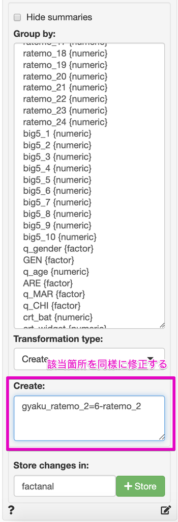

- これで一個一個やっていったら少しめんどくさいため，コピペをしてReport→Rmdを選んだほうが良い．
  - そのまま一気に複数作ってしまったほうが楽．

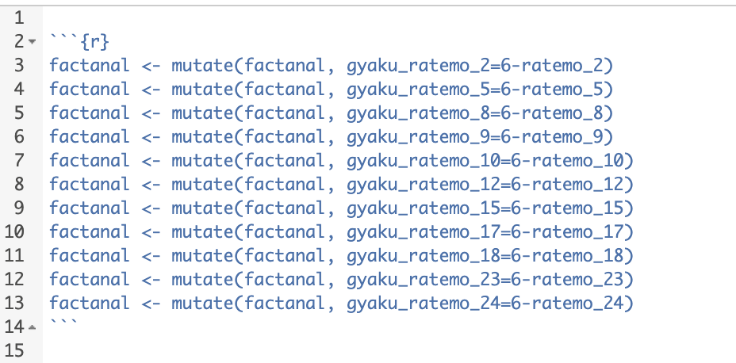

```r
library(readr)
factanal <- read_csv("../data/factanal.csv")
library(dplyr)
factanal <- mutate(factanal, gyaku_ratemo_2=6-ratemo_2)
factanal <- mutate(factanal, gyaku_ratemo_5=6-ratemo_5)
factanal <- mutate(factanal, gyaku_ratemo_8=6-ratemo_8)
factanal <- mutate(factanal, gyaku_ratemo_9=6-ratemo_9)
factanal <- mutate(factanal, gyaku_ratemo_10=6-ratemo_10)
factanal <- mutate(factanal, gyaku_ratemo_12=6-ratemo_12)
factanal <- mutate(factanal, gyaku_ratemo_15=6-ratemo_15)
factanal <- mutate(factanal, gyaku_ratemo_17=6-ratemo_17)
factanal <- mutate(factanal, gyaku_ratemo_18=6-ratemo_18)
factanal <- mutate(factanal, gyaku_ratemo_23=6-ratemo_23)
factanal <- mutate(factanal, gyaku_ratemo_24=6-ratemo_24)
```

#### 分析をしよう

- Multivariate→Pre-factor

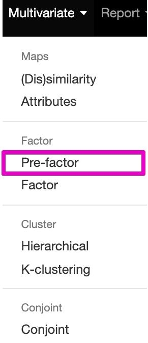

- 逆転項目と正規項目をもれなく入れる．

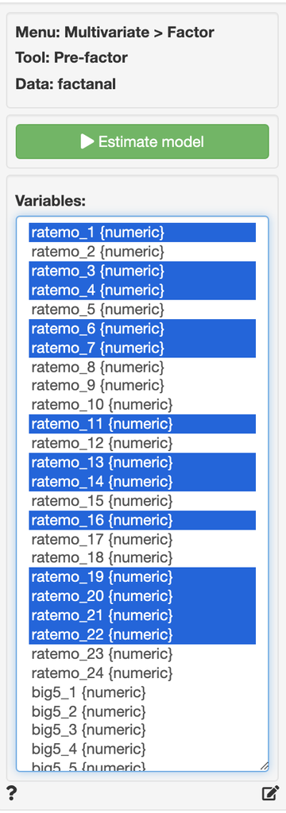

```r
library(radiant)
result <- pre_factor(
  factanal,
  vars = c(
    "ratemo_1", "ratemo_3", "ratemo_4", "ratemo_6", "ratemo_7",
    "ratemo_11", "ratemo_13", "ratemo_14", "ratemo_16", "ratemo_19",
    "ratemo_20", "ratemo_21", "ratemo_22", "gyaku_ratemo_2",
    "gyaku_ratemo_5", "gyaku_ratemo_8", "gyaku_ratemo_9", "gyaku_ratemo_10",
    "gyaku_ratemo_12", "gyaku_ratemo_15", "gyaku_ratemo_17",
    "gyaku_ratemo_18", "gyaku_ratemo_23", "gyaku_ratemo_24"
  )
)
summary(result, dec = 2)
```

```
## Pre-factor analysis diagnostics
## Data        : factanal
## Variables   : ratemo_1, ratemo_3, ratemo_4, ratemo_6, ratemo_7, ratemo_11, ratemo_13, ratemo_14, ratemo_16, ratemo_19, ratemo_20, ratemo_21, ratemo_22, gyaku_ratemo_2, gyaku_ratemo_5, gyaku_ratemo_8, gyaku_ratemo_9, gyaku_ratemo_10, gyaku_ratemo_12, gyaku_ratemo_15, gyaku_ratemo_17, gyaku_ratemo_…
## Observations: 794
##
## Bartlett test
## Null hyp. : variables are not correlated
## Alt. hyp. : variables are correlated
## Chi-square: 8548.38 df(276), p.value < .001
##
## KMO test:  0.9
##
## Variable collinearity:
##                  Rsq  KMO
## ratemo_1        0.60 0.88
## ratemo_3        0.41 0.90
## ratemo_4        0.62 0.87
## ratemo_6        0.49 0.92
## ratemo_7        0.31 0.86
## ratemo_11       0.40 0.92
## ratemo_13       0.44 0.91
## ratemo_14       0.38 0.90
## ratemo_16       0.60 0.92
## ratemo_19       0.52 0.91
## ratemo_20       0.59 0.91
## ratemo_21       0.22 0.91
## ratemo_22       0.48 0.91
## gyaku_ratemo_2  0.33 0.90
## gyaku_ratemo_5  0.55 0.90
## gyaku_ratemo_8  0.46 0.92
## gyaku_ratemo_9  0.41 0.90
## gyaku_ratemo_10 0.49 0.91
## gyaku_ratemo_12 0.34 0.85
## gyaku_ratemo_15 0.58 0.92
## gyaku_ratemo_17 0.52 0.87
## gyaku_ratemo_18 0.47 0.89
## gyaku_ratemo_23 0.59 0.93
## gyaku_ratemo_24 0.53 0.92
##
## Fit measures:
```

[output cut: 10 more lines]

```
##  PC10        0.58       0.02         0.77
##  PC11        0.56       0.02         0.79
##  PC12        0.53       0.02         0.81
##  PC13        0.52       0.02         0.83
##  PC14        0.50       0.02         0.85
##  PC15        0.44       0.02         0.87
##  PC16        0.42       0.02         0.89
##  PC17        0.41       0.02         0.91
##  PC18        0.37       0.02         0.92
##  PC19        0.35       0.01         0.94
##  PC20        0.34       0.01         0.95
##  PC21        0.33       0.01         0.97
##  PC22        0.30       0.01         0.98
##  PC23        0.28       0.01         0.99
##  PC24        0.25       0.01         1.00
```

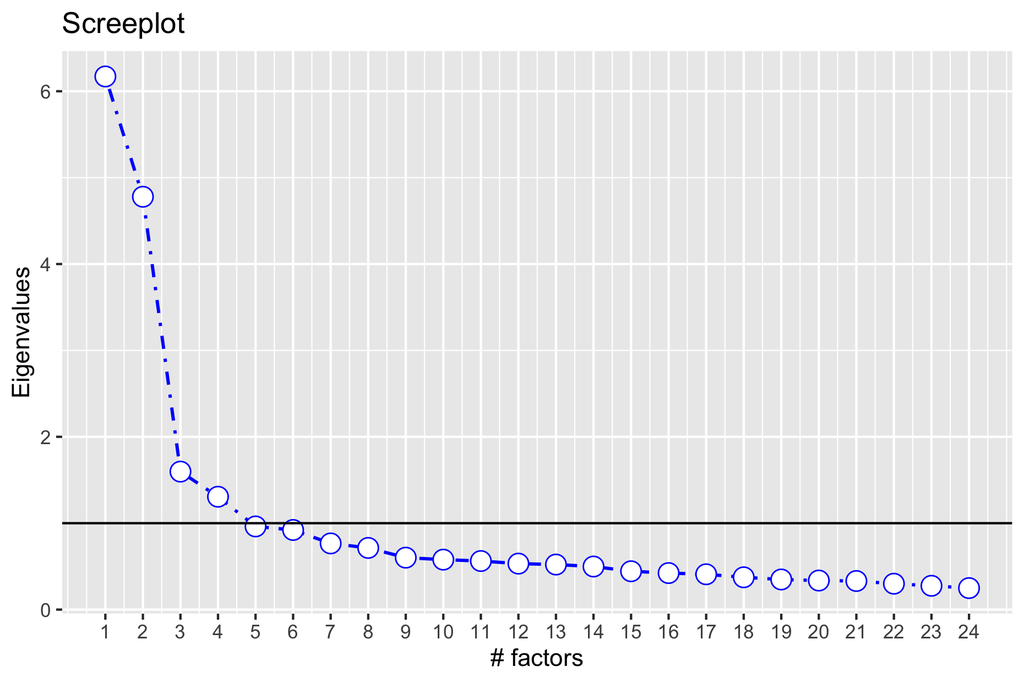

```r
plot(result, plots = "scree", custom = FALSE)
```

- Screeplot：ある成分や因子に対して，それに対応する固有値を降順でプロットしたグラフのこと． 因子や成分の寄与の大きさの指標となる．
  - 固有値がガクッと曲がっているところが因子数の基準．
  - 固有値：分散の大きさの基準．因子が増えると分散を小さくできるけど，たくさんあるとめんどいから，程々のところで考えよう．

## 因子数を確認したあと．．

- 因子分析にはいくつかのスタンスがある．
  - 探索的因子分析：どのような因子存在して影響を与えているのか，よくわからない場合などに用いる．
    - ex.新しい質問紙を使う時に用いる
  - 確証的因子分析：先行研究や仮説にあわせて因子数を確認する
    - ex.今回は確証的因子分析をもとにしてよい
- Multivariate→Factor

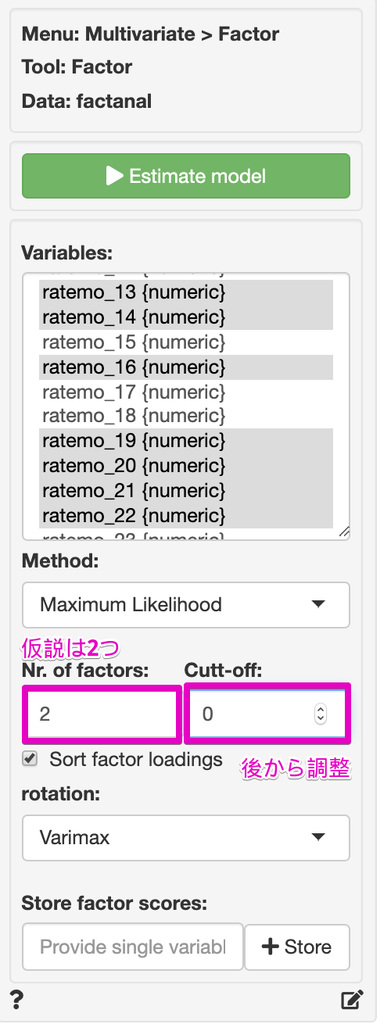

```r
result <- full_factor(
  factanal,
  vars = c(
    "ratemo_1", "ratemo_3", "ratemo_4", "ratemo_6", "ratemo_7",
    "ratemo_11", "ratemo_13", "ratemo_14", "ratemo_16", "ratemo_19",
    "ratemo_20", "ratemo_21", "ratemo_22", "gyaku_ratemo_2",
    "gyaku_ratemo_5", "gyaku_ratemo_8", "gyaku_ratemo_9", "gyaku_ratemo_10",
    "gyaku_ratemo_12", "gyaku_ratemo_15", "gyaku_ratemo_17",
    "gyaku_ratemo_18", "gyaku_ratemo_23", "gyaku_ratemo_24"
  ),
  method = "maxlik",
  nr_fact = 2
)
summary(result, cutoff = 0, fsort = TRUE, dec = 2)
```

```
## Factor analysis
## Data        : factanal
## Variables   : ratemo_1, ratemo_3, ratemo_4, ratemo_6, ratemo_7, ratemo_11, ratemo_13, ratemo_14, ratemo_16, ratemo_19, ratemo_20, ratemo_21, ratemo_22, gyaku_ratemo_2, gyaku_ratemo_5, gyaku_ratemo_8, gyaku_ratemo_9, gyaku_ratemo_10, gyaku_ratemo_12, gyaku_ratemo_15, gyaku_ratemo_17, gyaku_ratemo_…
## Factors     : 2
## Method      : maxlik
## Rotation    : varimax
## Observations: 794
##
## Factor loadings:
##                   ML1   ML2
## gyaku_ratemo_23  0.75  0.04
## ratemo_16        0.73  0.04
## gyaku_ratemo_15  0.73  0.12
## ratemo_20        0.70  0.09
## gyaku_ratemo_24  0.68  0.05
## ratemo_4         0.68 -0.09
## ratemo_1         0.67  0.01
## ratemo_6         0.66  0.02
## gyaku_ratemo_5   0.66  0.01
## gyaku_ratemo_8   0.63 -0.11
## gyaku_ratemo_10  0.63  0.04
## ratemo_14        0.46  0.12
## ratemo_19       -0.11  0.74
## ratemo_22        0.06  0.71
## gyaku_ratemo_17 -0.01  0.68
## gyaku_ratemo_18  0.12  0.63
## ratemo_13       -0.23  0.63
## ratemo_11        0.03  0.62
## ratemo_3         0.11  0.57
## gyaku_ratemo_9   0.21  0.56
## gyaku_ratemo_2   0.00  0.54
## gyaku_ratemo_12 -0.06  0.47
## ratemo_21        0.02  0.44
## ratemo_7         0.19  0.40
##
## Fit measures:
##               ML1  ML2
## Eigenvalues  5.53 4.28
## Variance %   0.23 0.18
## Cumulative % 0.23 0.41
```

[output cut: 24 more lines]

```
## gyaku_ratemo_23 55.82%
## gyaku_ratemo_24 46.49%
##
## Factor scores (max 10 shown):
##    ML1   ML2
##  -0.61  0.21
##   0.59 -1.28
##  -0.40  0.97
##  -1.17  2.57
##   0.48  1.61
##   0.32  0.69
##   0.07  0.45
##   0.77  0.51
##  -1.07 -0.07
##   1.28 -0.21
```

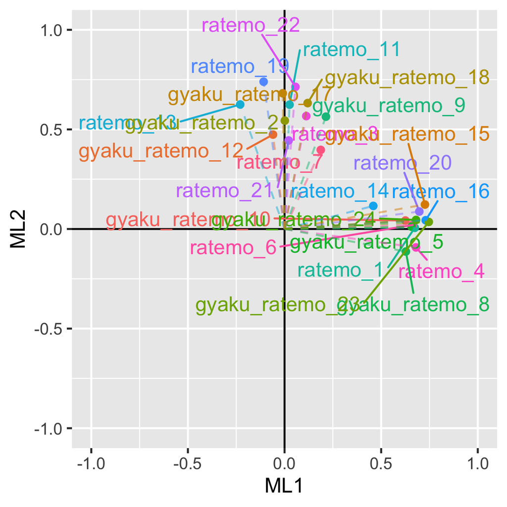

```r
plot(result, custom = FALSE)
```

- cutoffを0.3に設定

```r
result <- full_factor(
  factanal,
  vars = c(
    "ratemo_1", "ratemo_3", "ratemo_4", "ratemo_6", "ratemo_7",
    "ratemo_11", "ratemo_13", "ratemo_14", "ratemo_16", "ratemo_19",
    "ratemo_20", "ratemo_21", "ratemo_22", "gyaku_ratemo_2",
    "gyaku_ratemo_5", "gyaku_ratemo_8", "gyaku_ratemo_9", "gyaku_ratemo_10",
    "gyaku_ratemo_12", "gyaku_ratemo_15", "gyaku_ratemo_17",
    "gyaku_ratemo_18", "gyaku_ratemo_23", "gyaku_ratemo_24"
  ),
  method = "maxlik",
  nr_fact = 2
)
summary(result, cutoff = 0.3, fsort = TRUE, dec = 2)
```

```
## Factor analysis
## Data        : factanal
## Variables   : ratemo_1, ratemo_3, ratemo_4, ratemo_6, ratemo_7, ratemo_11, ratemo_13, ratemo_14, ratemo_16, ratemo_19, ratemo_20, ratemo_21, ratemo_22, gyaku_ratemo_2, gyaku_ratemo_5, gyaku_ratemo_8, gyaku_ratemo_9, gyaku_ratemo_10, gyaku_ratemo_12, gyaku_ratemo_15, gyaku_ratemo_17, gyaku_ratemo_…
## Factors     : 2
## Method      : maxlik
## Rotation    : varimax
## Observations: 794
##
## Factor loadings:
##                  ML1  ML2
## gyaku_ratemo_23 0.75
## ratemo_16       0.73
## gyaku_ratemo_15 0.73
## ratemo_20        0.7
## gyaku_ratemo_24 0.68
## ratemo_4        0.68
## ratemo_1        0.67
## ratemo_6        0.66
## gyaku_ratemo_5  0.66
## gyaku_ratemo_8  0.63
## gyaku_ratemo_10 0.63
## ratemo_14       0.46
## ratemo_19            0.74
## ratemo_22            0.71
## gyaku_ratemo_17      0.68
## gyaku_ratemo_18      0.63
## ratemo_13            0.63
## ratemo_11            0.62
## ratemo_3             0.57
## gyaku_ratemo_9       0.56
## gyaku_ratemo_2       0.54
## gyaku_ratemo_12      0.47
## ratemo_21            0.44
## ratemo_7              0.4
##
## Fit measures:
##               ML1  ML2
## Eigenvalues  5.53 4.28
## Variance %   0.23 0.18
## Cumulative % 0.23 0.41
```

[output cut: 24 more lines]

```
## gyaku_ratemo_23 55.82%
## gyaku_ratemo_24 46.49%
##
## Factor scores (max 10 shown):
##    ML1   ML2
##  -0.61  0.21
##   0.59 -1.28
##  -0.40  0.97
##  -1.17  2.57
##   0.48  1.61
##   0.32  0.69
##   0.07  0.45
##   0.77  0.51
##  -1.07 -0.07
##   1.28 -0.21
```

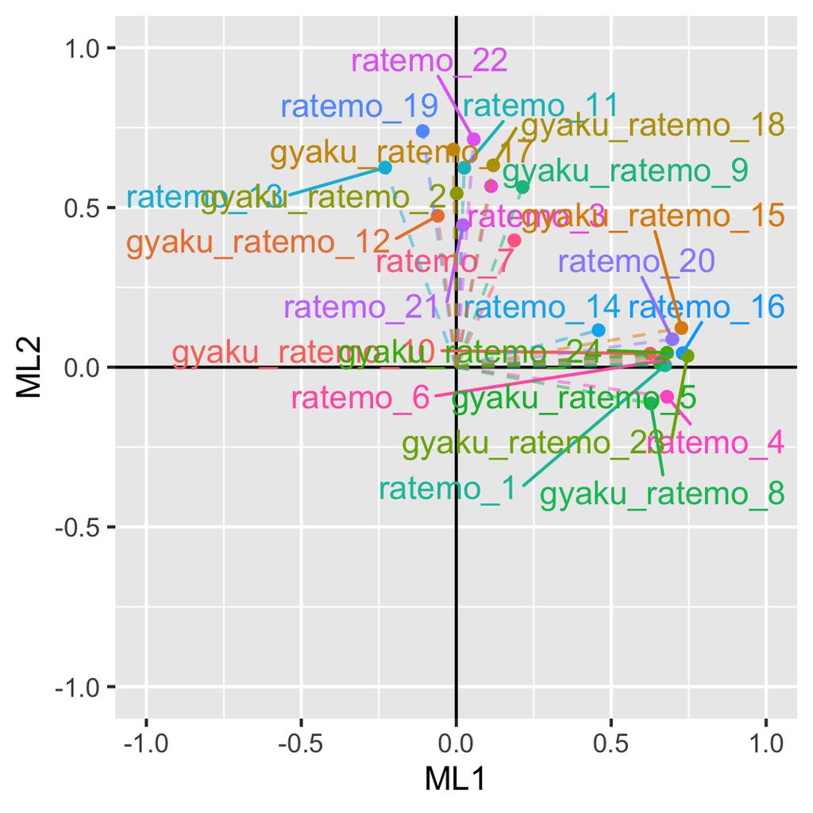

```r
plot(result, custom = FALSE)
```

# 資料

## 演習問題：

- 以下の問題を回答してください．
- 各自で以下の論文を読みながら，BIG5データについて因子分析を行ってください．
- データは先程配布したデータの中にある．項目の順番は参考資料②の通り．
- **[参考資料①](https://www.jstage.jst.go.jp/article/personality/21/1/21_40/_pdf/-char/ja)**
- **[参考資料②](http://www.f.waseda.jp/oshio.at/research/scales/TIPI-J.pdf)**

## 今日のTake Home Messages

- データ解析論I（春学期）とデータ解析論II（秋学期）を履修しなければ，社会調査士E科目として認定されない．
- **[R](https://www.r-project.org/)**と**[RStudio](https://www.rstudio.com/)**というプログラムを用いる．
- **[Google アカウント](https://accounts.google.com/signup)**を作成しておく必要がある．
- 最初のデータ整理やグループワークに用いる．
- 自身で保有するパソコンにインストールすることをおすすめするが，様々な制約が存在する．
- ex.日本語（2バイト文字）でユーザ名やフォルダ名を作っていたらエラーが生じるなど．
- その場合は自宅で実施するために**[RStudio Cloud](https://rstudio.cloud/)**を用いることを推奨する．
- しかし，動作は今研究中なので対応できないことがあるかもしれません．．．．

## Rでデータを扱う時に注意すべきこと

- 必ず数字／文字は半角で入力する．
- 日本語は使わずにローマ字を使用する．
- コメントアウト（コードではなく，関係ないメモを入れること）をするときは半角の「#」から始める．
- メモする内容は全角でもよい．
- ファイル名およびパスには決して全角の文字（ひらがな，カタカナ，漢字，全角スペースなど）を入れてはいけない．
- 半角英数字だけにする．
- 慌てずに落ち着いて操作すれば，決して難しくない．
- 1つずつ落ち着いて作業することを心がける．
- 「わからない」ことを恐れない
- 周りの友人に聞いたり，教員に確認したりしよう．

### リアクションペーパー：

- 授業で学んだことおよび感想を下記リンクからお答えください． [リアクションペーパー](https://forms.gle/DqVa7ea9py9biejJ7)

## 参考文献など

### 参考図書（和書）

*統計について*

- [山田剛史, 杉澤武俊, 村井潤一郎, 2008, 『Rによる優しい統計学』, オーム社, *明治e-libへ*](https://elib.maruzen.co.jp/elib/html/BookDetail/Id/3000002659?7)
- 基本的な考え方を紹介してくれる本．oh-o!Meijiにログインすれば無料で読める．
- [内田治, 西澤英子 2008, 『Rによる統計的検定と推定』, オーム社, *明治e-libへ*](https://elib.maruzen.co.jp/elib/html/BookDetail/Id/3000002728?9)
- 基本的な考え方を紹介してくれる本．oh-o!Meijiにログインすれば無料で読める．
- [奥村晴彦 2008, 『Rによる統計的検定と推定』, オーム社, *明治e-libへ*](https://elib.maruzen.co.jp/elib/html/BookDetail/Id/3000002728?9)
- 基本的な考え方を紹介してくれる本．oh-o!Meijiにログインすれば無料で読める．
- [小杉考司, 2019, 『言葉と数式で理解する多変量解析入門』, 北大路出版](https://www.amazon.co.jp/dp/476283047X)
- 非常に平易な言葉で多変量解析について説明がなされている．ただし，一歩戻って基本的RStudioの使い方と基本的な統計(t検定や回帰分析，カイ2乗検定など)を学ぶのであれば，[小杉考司, 2019, 『Rでらくらく心理統計 RStudio徹底活用』](https://www.amazon.co.jp/dp/4065144876)などもよいでしょう．
- [星野匡郎, 田中久稔, 2018, 『Rによる実証分析 ―回帰分析から因果分析へ―』, 裳華房](https://www.amazon.co.jp/dp/427421947X)
- Rを用いた様々な分析手法について記載されている．春学期の内容も含まれるが，主に秋学期の内容をカバーしている．
- [川端一光, 岩間徳兼, 鈴木雅之, 2018, 『Rによる多変量解析入門 - データ解析の実践と理論』, オーム社](https://www.amazon.co.jp/dp/4274222365/)
- 基本的な技術を学ぶことができる．かなり良書．
- *この講義の作成にかなり使っています．*
  - [森田果, 2014, 『実証分析入門 - データから「因果関係」を読み解く作法』, 日本評論社](https://www.amazon.co.jp/dp/4535557934)
- 法律系の先生が書かれた本だが，なかなかわかりやすく面白い．どちらかというと秋学期の内容に関わる．
- [地道正行, 2018, 『データサイエンスの基礎 Rによる統計学独習』, 裳華房](https://www.amazon.co.jp/dp/4785315784)
- 細かく書かれているが，数式も多い．講義内で数学的説明の時間を十分に確保できないため，興味のある方はこちらへ．

*再現性の議論について*

- [高橋康介, 2018, 『再現可能性のすゝめ (Wonderful R 3)』, 共立出版](https://www.amazon.co.jp/dp/4320112431)
- [江口哲史(編), 2018『自然科学研究のためのR入門―再現可能なレポート執筆実践― (Wonderful R 4)』, 共立出版](https://www.amazon.co.jp/dp/432011244X)
- いずれの本も再現可能性のためにRStudioとRMarkdownの使い方について紹介した本．

*分析の一連の流れについて*

- [岩波データサイエンス](https://elib.maruzen.co.jp/elib/html/SeriesDetail/Id/3000047689?28)
- 様々な応用的な統計の考え方を紹介している．
- [松村優哉, 湯谷啓明, 紀ノ定保礼, 前田和寛, 2018, 『RユーザのためのRStudio[実践]入門−tidyverseによるモダンな分析フローの世界』, 技術評論社](https://www.amazon.co.jp/dp/4774198536/)
- RStudioを用いたデータ収集，データ整形，可視化，レポーティングといった一連の分析の流れに関する本．

### 参考図書（洋書）

*計量経済について* * [Heiss, Florian, 2016, “Using R for Introductory Econometrics”, Amazon Digital Services](https://www.amazon.co.jp/dp/1523285133/) - 洋書．Rを用いた計量経済学入門の教科書だが，手を動かしながら学んでいくことができる．

### 参考web資料

*Rによる統計* * [Rjpwiki](http://www.okadajp.org/RWiki/) - Rに関する基礎知識の共有などが図られている．

- r-wakalang
- Slackのグループ．全く知らない人たちが色々質問に答えてくれたりも．
- [からだにいいもの](https://www.karada-good.net)
- Rに関する様々な情報が掲載されている．多少応用的なトピックが多い．
- [marketechlabo](https://www.marketechlabo.com/r-best-packages/)
- ちょっと新しいパッケージ等が紹介されていて興味深い

*RMarkdownの使い方*

- [R Markdown入門](https://kazutan.github.io/kazutanR/Rmd_intro.html)
- Rマークダウンに限らずデータ操作や可視化などの技術についても[他ページ](https://kazutan.github.io/kazutanR/index.html)で紹介している．
- [R Markdownで楽々レポートづくり](http://gihyo.jp/admin/serial/01/r-markdown/0001)
- 全8話のRMarkdownの操作方法について．この記事の内容は[高橋康介, 2014, 『ドキュメント・プレゼンテーション生成 (シリーズ Useful R 9)』, 共立出版](https://www.amazon.co.jp/dp/4320123727)をもとに作成されている．しかし，この記事を読めばよく分かる．．．

## ヒント

- こんなことがかかわるかも？
- なんて，演習問題によってヒントが出たり何だりします．
- ヒントがない時は気合でがんばりましょう．

## データの概要

### データの頭10個

```r
library(DT)
library(readr)
exdataset <- read_csv("/Users/akira/Dropbox/Education/2019MEIJI/[3_Wed2]Data_Analytics/analysis/data/exdataset.csv")
DT::datatable(exdataset)
```

|  | SUB_HAP | SUB_SAT | SUB_SLP | DIC_PAR | DIC_FRI | DIC_OTH | ULT_PRO_PAR | ULT_PRO_FRI | ULT_PRO_OTH | ULT_REC_PAR | ULT_REC_FRI | ULT_REC_OTH | TRU_PAR | TRU_FRI | TRU_OTH | SPN_UNM | SPN_THK | SPN_FEA | SPN_LIV | SPN_IMP | KAN_SEC | KAN_THI | KAN_SUP | KAN_PRD | KAN_KYK | DED_SHI | DED_TEN | DED_JIG | DED_KIS | … |
| --- | --- | --- | --- | --- | --- | --- | --- | --- | --- | --- | --- | --- | --- | --- | --- | --- | --- | --- | --- | --- | --- | --- | --- | --- | --- | --- | --- | --- | --- | --- |
| 1 | 4 | 4 | 9 | 10 | 5 | 3 | 10 | 5 | 5 | 0 | 1 | 1 | 10 | 5 | 3 | 1 | 3 | 3 | 3 | 4 | 1 | 2 | 1 | 2 | 3 | 1 | 1 | 1 | 3 | … |
| 2 | 6 | 5 | 8 | 3 | 1 | 0 | 3 | 5 | 7 | 3 | 5 | 5 | 2 | 1 | 0 | 2 | 3 | 3 | 2 | 3 | 3 | 3 | 2 | 2 | 3 | 2 | 2 | 2 | 3 | … |
| 3 | 5 | 3 | 3 | 10 | 5 | 0 | 10 | 5 | 0 | 10 | 5 | 0 | 10 | 5 | 0 | 2 | 3 | 3 | 2 | 3 | 3 | 3 | 3 | 2 | 2 | 3 | 2 | 2 | 3 | … |
| 4 | 5 | 5 | 4 | 2 | 0 | 0 | 5 | 5 | 5 | 5 | 5 | 5 | 2 | 2 | 2 | 4 | 3 | 3 | 3 | 3 | 2 | 2 | 4 | 4 | 3 | 2 | 2 | 2 | 3 | … |
| 5 | 3 | 3 | 2 | 0 | 0 | 0 | 5 | 5 | 0 | 5 | 5 | 0 | 10 | 10 | 1 | 1 | 2 | 3 | 3 | 3 | 1 | 1 | 1 | 1 | 3 | 4 | 4 | 4 | 2 | … |
| 6 | 7 | 7 | 6 | 3 | 1 | 0 | 3 | 1 | 0 | 3 | 1 | 0 | 5 | 3 | 0 | 3 | 3 | 3 | 3 | 3 | 3 | 3 | 2 | 3 | 3 | 3 | 3 | 3 | 3 | … |
| 7 | 5 | 5 | 6 | 5 | 2 | 0 | 5 | 3 | 2 | 0 | 1 | 1 | 10 | 5 | 0 | 2 | 2 | 2 | 2 | 3 | 3 | 3 | 1 | 3 | 4 | 4 | 2 | 4 | 2 | … |
| 8 | 5 | 5 | 8 | 5 | 5 | 0 | 5 | 5 | 0 | 5 | 5 | 0 | 5 | 8 | 0 | 4 | 4 | 4 | 4 | 3 | 4 | 4 | 4 | 3 | 3 | 3 | 3 | 3 | 3 | … |
| 9 | 1 | 3 | 1 | 10 | 5 | 0 | 10 | 5 | 0 | 10 | 5 | 0 | 10 | 8 | 4 | 3 | 4 | 4 | 4 | 4 | 3 | 1 | 1 | 1 | 3 | 3 | 3 | 3 | 4 | … |
| 10 | 7 | 7 | 5 | 5 | 5 | 0 | 5 | 5 | 5 | 5 | 5 | 0 | 3 | 3 | 0 | 2 | 3 | 3 | 3 | 3 | 2 | 2 | 2 | 2 | 3 | 2 | 2 | 2 | 3 | … |

[output cut: 953 more lines]

### 変数名リスト

#### 主観的指標

[output not shown]

#### 独裁者ゲーム

図を見て下さい.  
あなたはAさんです. あなたはTポイントを10ポイントを受け取りました.  
そのうち，あなたはBさんに何ポイントかを渡すことができます．  
さて，あなたはBさんに何ポイント渡しますか？  
ここでは以下の条件の場合について教えて下さい.

[output not shown]

#### 最終提案ゲーム_提案者

図を見て下さい.  
あなたはAさんです. あなたはTポイントを10ポイントを受け取りました.  
そのうち，あなたはBさんとポイントを分け合うことになりました．  
あなたは，Bさんに対して分け合うポイントを提案することができます．  
あなたは，10ポイントの中から，Bさんに対して分けたポイントを引いた残りを受け取ることができます．  
しかし，Bさんがあなたの提案を拒否した場合には，その提案は実現せずに，  
お互いポイントをもらえないことになります．  
さて，あなたはBさんに何ポイント渡すことを提案しますか？  
ここでは以下の条件の場合について教えて下さい.

| 項目名 | データタイトル | 質問項目 | 回答 |
| --- | --- | --- | --- |
| 最終提案提案者両親条件 | ULT_PRO_PAR | Bさんが両親の場合 | 0ポイント-10ポイント |
| 最終提案提案者友人条件 | ULT_PRO_FRI | Bさんが友人の場合 | 0ポイント-10ポイント |
| 最終提案提案者他者条件 | ULT_PRO_OTH | Bさんが全く知らない他人の場合 | 0ポイント-10ポイント |

#### 最終提案ゲーム_応答者

図を見て下さい. あなたはBさんです. AさんはTポイントを10ポイントを受け取りました.  
Aさんが，あなたに対して分け合うポイントを提案します．  
Aさんは，10ポイントの中から，あなたに対して分けたポイントを引いた残りを受け取ることができます．  
しかし，あなたがAさんの提案を拒否した場合には，その提案は実現せずに，  
お互いポイントをもらえないことになります．  
さて，最低でも何ポイントの提案を受けたら，Aさんの提案を受け入れますか？  
ここでは以下の条件の場合について教えて下さい.

| 項目名 | データタイトル | 質問項目 | 回答 |
| --- | --- | --- | --- |
| 最終提案応答者両親条件 | ULT_REC_PAR | Bさんが両親の場合 | 0ポイント-10ポイント |
| 最終提案応答者友人条件 | ULT_REC_FRI | Bさんが友人の場合 | 0ポイント-10ポイント |
| 最終提案応答者他者条件 | ULT_REC_OTH | Bさんが全く知らない他人の場合 | 0ポイント-10ポイント |

#### 信頼ゲーム

図を見て下さい.  
あなたはAさんです. あなたはTポイントを10ポイント持っています.  
いくらかをCさんにあずけてください. CさんはあなたからあずかったTポイントを3倍にしてBさんに渡します.  
Bさんは手元に渡されたポイントのうち，いくらかをあなたに返します.  
この時，あなたはCさんにいくらあずけますか？  
ここではBさんが以下の条件の場合について教えて下さい.

| 項目名 | データタイトル | 質問項目 | 回答 |
| --- | --- | --- | --- |
| 信頼両親条件 | TRU_PAR | Bさんが両親の場合 | 0ポイント-10ポイント |
| 信頼友人条件 | TRU_FRI | Bさんが友人の場合 | 0ポイント-10ポイント |
| 信頼他者条件 | TRU_OTH | Bさんが全く知らない他人の場合 | 0ポイント-10ポイント |

#### 自然関連

以下の質問について4点満点でお答えください．

| 項目名 | データタイトル | 質問項目 | 回答 |
| --- | --- | --- | --- |
| 自然運命 | SPN_UNM | 何かの大きな力に自分の運命は動かされているように感じることがある. | 1全くそう思わない-4非常にそう思う |
| 自然感謝 | SPN_THK | 自然などの人間を超えた力に感謝の気持ちを持つことがある. | 1全くそう思わない-4非常にそう思う |
| 自然恐怖 | SPN_FEA | 自然などの人間を超えた力に恐れの気持ちを持つことがある. | 1全くそう思わない-4非常にそう思う |
| 自然生存 | SPN_LIV | 自然などの人間を超えた力によって，生かされていると思うことがある. | 1全くそう思わない-4非常にそう思う |
| 自然大切 | SPN_IMP | 自然は大切な存在である． | 1全くそう思わない-4非常にそう思う |

#### 監視

以下の質問について4点満点でお答えください．

[output not shown]

#### 死後

以下の質問について4点満点でお答えください．

| 項目名 | データタイトル | 質問項目 | 回答 |
| --- | --- | --- | --- |
| 死後世界 | DED_SHI | 「死後の世界」が存在すると思いますか？ | 1全くそう思わない-4非常にそう思う |
| 天国 | DED_TEN | 「天国」が存在すると思いますか？ | 1全くそう思わない-4非常にそう思う |
| 地獄 | DED_JIG | 「地獄」が存在すると思いますか？ | 1全くそう思わない-4非常にそう思う |
| 奇跡 | DED_KIS | 「奇跡」が存在すると思いますか？ | 1全くそう思わない-4非常にそう思う |
| 天罰 | DED_PUN | 「天罰」が存在すると思いますか？ | 1全くそう思わない-4非常にそう思う |

#### 性行動

以下の質問についてお答えください．

[output not shown]

#### フェイスシート

あなたのことについて教えて下さい．

| 項目名 | データタイトル | 質問項目 | 回答 |
| --- | --- | --- | --- |
| 性別 | F_SEX | あなたの性別を教えて下さい. | 1.男性, 2.女性,3.その他 |
| 世代 | F_GEN | あなたの年齢を教えて下さい. | 1. 10代前半, 2. 10代後半, 3. 20代前半, 4. 20代後半, 5. 30代前半, 6. 30代後半, 7. 40代前半, 8. 40代後半, 9. 50代前半, 10. 50代前半, 11. 60代前半, 12. 60代後半, 13. 70代以降 |
| 最終学歴 | F_FGR | あなたの最終学歴を教えて下さい. | 1. 中学校卒業, 2. 高校中退, 3. 高校卒業, 4. 専門学校（短期大学）中退, 5. 専門学校（短期大学）卒業, 6. 大学中退, 7. 大学卒業, 8. 大学院修士課程（博士前期課程）中退, 9. 大学院修士課程（博士前期課程）修了, 10. 大学院博士課程（博士後期課程）中退, 11. 大学院博士課程（博士後期課程）修了 |
| 個人収入 | F_INK，F_INK_cen(中央値，百万円) | あなた個人の年収を教えて下さい. | 0. 0円, 1. 1円〜200万円未満, 2. 200万円以上〜400万円未満, 3. 400万円以上〜600万円未満, 4. 600万円以上〜800万円未満, 5. 800万円以上〜1,000万円未満, 6. 1,000万円以上〜1,200万円未満, 7. 1,200万円以上〜1,500万円未満, 8. 1,500万円以上〜2,000万円未満, 9. 2,000万円以上, 10. わからない |
| 世帯収入 | F_INS，F_INS_cen(中央値，百万円) | あなたの世帯での収入の合計を教えて下さい. | 0. 0円, 1. 1円〜200万円未満, 2. 200万円以上〜400万円未満, 3. 400万円以上〜600万円未満, 4. 600万円以上〜800万円未満, 5. 800万円以上〜1,000万円未満, 6. 1,000万円以上〜1,200万円未満, 7. 1,200万円以上〜1,500万円未満, 8. 1,500万円以上〜2,000万円未満, 9. 2,000万円以上, 10. わからない |
| 回答端末 | F_TAN | あなたが現在回答に使われているケータイ／タブレット／パソコンについて，当てはまるものを選んで下さい． | 1. パソコン（Windows）, 2. パソコン（Mac）, 3. パソコン（その他）, 4. タブレット（Windows）, 5. タブレット（iOS，iPad）, 6. タブレット（android）, 7. タブレット（その他）, 8. スマホ（Windows）, 9. スマホ（iOS，iPhone）, 10. スマホ（android）, 11. スマホ（その他）, 12. ガラケー，フィー… |
| 都道府県 | PRE | あなたのお住まいの県を教えて下さい. | 1. 北海道2. 青森県3. 岩手県4. 宮城県5. 秋田県6. 山形県7. 福島県8. 茨城県9. 栃木県10. 群馬県11. 埼玉県12. 千葉県13. 東京都14. 神奈川県15. 新潟県16. 富山県17. 石川県18. 福井県19. 山梨県20. 長野県21. 岐阜県22. 静岡県23. 愛知県24. 三重県25. 滋賀県26. 京都府27. 大阪府28. 兵庫県29. 奈良県30. 和… |
| 地域 | ARE | 都道府県から地域に変換 | 北海道：1. 北海道，東北地方：2. 青森県3. 岩手県4. 宮城県5. 秋田県6. 山形県7. 福島県，関東地方：8. 茨城県9. 栃木県10. 群馬県11. 埼玉県12. 千葉県13. 東京都14. 神奈川県，中部地方：15. 新潟県16. 富山県17. 石川県18. 福井県19. 山梨県20. 長野県21. 岐阜県22. 静岡県23. 愛知県24. 三重県，近畿地方：25. 滋賀県26. 京… |
| 未既婚 | MAR | あなたはご結婚されていますか？ | NotMarried：未婚，Married：既婚 |
| 子の有無 | CHI | あなたはお子さんがいらっしゃいますか？ | NoChild：いない，Child：いる |